# Bando et al_Altair Final Clinical Analysis

library(swimplot) library(coxphf) library(grid) library(gtable) library(readr) library(mosaic) library(dplyr) library(survival) library(survminer) library(gridtext) library(ggplot2) library(scales) library(officer) library(ggthemes) library(tidyverse) library(gtsummary) library(flextable) library(parameters) library(car) library(grid) library(FSA) library(ComplexHeatmap) library(readxl) library(janitor) library(rms) library(pROC) library(DT)

#Demographics Table by Altair Arm

```r
rm(list=ls())
setwd("~/Downloads")
circ_data <- read.csv("Altair 20240729 Dataset.csv")

circ_data_subset1 <- circ_data %>%
  select(
    Age.Group,
    Sex,
    PrimSitev2,
    StageA.alt,
    p_hadNeo,
    p_TxAdjAltair,
    ctDNA1mo,
    p_AltBaselineWin,
    BRAF.V600E,
    RAS,
    MSI) %>%
  mutate(
    Age.Group = factor(Age.Group, levels = c("1", "2"), labels = c("<70", ">70")),
    Sex = factor(Sex, levels = c("Male", "Female")),
    PrimSitev2 = factor(PrimSitev2, levels = c("Right-sided colon", "Left-sided colon", "Rectum")),
    StageA.alt = factor(StageA.alt, levels = c("I", "II", "III", "IV")),
    p_hadNeo = factor(p_hadNeo, levels=c("FALSE","TRUE"), labels = c("No", "Yes")),
    p_TxAdjAltair = factor(p_TxAdjAltair, levels=c("FALSE","TRUE"), labels = c("No", "Yes")),
    ctDNA1mo = factor(ctDNA1mo, levels = c("NEGATIVE", "POSITIVE"), labels = c("Negative", "Positive")),
    p_AltBaselineWin = factor(p_AltBaselineWin, levels = c("MRD", "OnTreatment", "Surveillance")),
    BRAF.V600E = factor(BRAF.V600E, levels = c("WT", "MUT"), labels = c("BRAF wt", "BRAF V600E")),
    RAS = factor(RAS, levels = c("WT", "MUT"), labels = c("RAS wt", "RAS mut")),
    MSI = factor(MSI, levels = c("MSS", "MSI-High")))

circ_data1 <- read.csv("Altair 20240729 Dataset.csv")

circ_data_subset2 <- circ_data1 %>%
  select(
    Age.Group,
    Sex,
    PrimSitev2,
    StageA.alt,
    p_hadNeo,
    p_TxAdjAltair,
    ctDNA1mo,
    p_AltBaselineWin,
    BRAF.V600E,
    RAS,
    MSI,
    altair.Arm) %>%
  mutate(
    Age.Group = factor(Age.Group, levels = c("1", "2"), labels = c("<70", ">70")),
    Sex = factor(Sex, levels = c("Male", "Female")),
    PrimSitev2 = factor(PrimSitev2, levels = c("Right-sided colon", "Left-sided colon", "Rectum")),
    StageA.alt = factor(StageA.alt, levels = c("I", "II", "III", "IV")),
    p_hadNeo = factor(p_hadNeo, levels=c("FALSE","TRUE"), labels = c("No", "Yes")),
    p_TxAdjAltair = factor(p_TxAdjAltair, levels=c("FALSE","TRUE"), labels = c("No", "Yes")),
    ctDNA1mo = factor(ctDNA1mo, levels = c("NEGATIVE", "POSITIVE"), labels = c("Negative", "Positive")),
    p_AltBaselineWin = factor(p_AltBaselineWin, levels = c("MRD", "OnTreatment", "Surveillance")),
    BRAF.V600E = factor(BRAF.V600E, levels = c("WT", "MUT"), labels = c("BRAF wt", "BRAF V600E")),
    RAS = factor(RAS, levels = c("WT", "MUT"), labels = c("RAS wt", "RAS mut")),
    MSI = factor(MSI, levels = c("MSS", "MSI-High")),
    altair.Arm = factor(altair.Arm, levels=c("Control","Experimental"), labels = c("Placebo", "FTD/TPI")))
Overall <- circ_data_subset1 %>%
  tbl_summary(
    statistic = list(
      all_continuous() ~ "{median} ({min} - {max})",
      all_categorical() ~ "{n} ({p}%)")) %>%
  bold_labels()
Overall
```

| **Characteristic** | **N = 243**<sup>1</sup> |
| --- | --- |
| Age.Group |  |
| <70 | 155 (64%) |
| >70 | 88 (36%) |
| Sex |  |
| Male | 142 (58%) |
| Female | 101 (42%) |
| PrimSitev2 |  |
| Right-sided colon | 60 (26%) |
| Left-sided colon | 127 (55%) |
| Rectum | 46 (20%) |
| Unknown | 10 |
| StageA.alt |  |
| I | 10 (4.1%) |
| II | 58 (24%) |
| III | 109 (45%) |
| IV | 66 (27%) |
| p_hadNeo | 87 (36%) |
| p_TxAdjAltair | 112 (46%) |
| ctDNA1mo |  |
| Negative | 113 (47%) |
| Positive | 130 (53%) |
| p_AltBaselineWin |  |
| MRD | 58 (24%) |
| OnTreatment | 33 (14%) |
| Surveillance | 152 (63%) |
| BRAF.V600E |  |
| BRAF wt | 234 (96%) |
| BRAF V600E | 9 (3.7%) |
| RAS |  |
| RAS wt | 148 (61%) |
| RAS mut | 95 (39%) |
| MSI |  |
| MSS | 238 (98%) |
| MSI-High | 5 (2.1%) |

<sup>1</sup> n (%)

```r
ByctDNA_MRD <- circ_data_subset2 %>%
  tbl_summary(
    by = altair.Arm, # add this line to subgroup by altair.Arm
    statistic = list(
      all_continuous() ~ "{median} ({min} - {max})",
      all_categorical() ~ "{n} ({p}%)")) %>%
  add_p() %>%
  bold_labels()
ByctDNA_MRD
```

| **Characteristic** | **Placebo** N = 121<sup>1</sup> | **FTD/TPI** N = 122<sup>1</sup> | **p-value**<sup>2</sup> |
| --- | --- | --- | --- |
| Age.Group |  |  | 0.8 |
| <70 | 78 (64%) | 77 (63%) |  |
| >70 | 43 (36%) | 45 (37%) |  |
| Sex |  |  | >0.9 |
| Male | 71 (59%) | 71 (58%) |  |
| Female | 50 (41%) | 51 (42%) |  |
| PrimSitev2 |  |  | >0.9 |
| Right-sided colon | 29 (25%) | 31 (26%) |  |
| Left-sided colon | 64 (56%) | 63 (53%) |  |
| Rectum | 22 (19%) | 24 (20%) |  |
| Unknown | 6 | 4 |  |
| StageA.alt |  |  | 0.6 |
| I | 3 (2.5%) | 7 (5.7%) |  |
| II | 30 (25%) | 28 (23%) |  |
| III | 56 (46%) | 53 (43%) |  |
| IV | 32 (26%) | 34 (28%) |  |
| p_hadNeo | 41 (34%) | 46 (38%) | 0.5 |
| p_TxAdjAltair | 56 (46%) | 56 (46%) | >0.9 |
| ctDNA1mo |  |  | >0.9 |
| Negative | 56 (46%) | 57 (47%) |  |
| Positive | 65 (54%) | 65 (53%) |  |
| p_AltBaselineWin |  |  | 0.5 |
| MRD | 30 (25%) | 28 (23%) |  |
| OnTreatment | 19 (16%) | 14 (11%) |  |
| Surveillance | 72 (60%) | 80 (66%) |  |
| BRAF.V600E |  |  | 0.5 |
| BRAF wt | 118 (98%) | 116 (95%) |  |
| BRAF V600E | 3 (2.5%) | 6 (4.9%) |  |
| RAS |  |  | 0.2 |
| RAS wt | 79 (65%) | 69 (57%) |  |
| RAS mut | 42 (35%) | 53 (43%) |  |
| MSI |  |  | 0.7 |
| MSS | 118 (98%) | 120 (98%) |  |
| MSI-High | 3 (2.5%) | 2 (1.6%) |  |

<sup>1</sup> n (%)  
<sup>2</sup> Pearson’s Chi-squared test; Fisher’s exact test

```r
merged_table <- tbl_merge(tbls=list(Overall, ByctDNA_MRD))
merged_table
```

| **Characteristic** | **Table 1** **N = 243**<sup>1</sup> | **Table 2** **Placebo** N = 121<sup>1</sup> | **Table 2** **FTD/TPI** N = 122<sup>1</sup> | **Table 2** **p-value**<sup>2</sup> |
| --- | --- | --- | --- | --- |
| Age.Group |  |  |  | 0.8 |
| <70 | 155 (64%) | 78 (64%) | 77 (63%) |  |
| >70 | 88 (36%) | 43 (36%) | 45 (37%) |  |
| Sex |  |  |  | >0.9 |
| Male | 142 (58%) | 71 (59%) | 71 (58%) |  |
| Female | 101 (42%) | 50 (41%) | 51 (42%) |  |
| PrimSitev2 |  |  |  | >0.9 |
| Right-sided colon | 60 (26%) | 29 (25%) | 31 (26%) |  |
| Left-sided colon | 127 (55%) | 64 (56%) | 63 (53%) |  |
| Rectum | 46 (20%) | 22 (19%) | 24 (20%) |  |
| Unknown | 10 | 6 | 4 |  |
| StageA.alt |  |  |  | 0.6 |
| I | 10 (4.1%) | 3 (2.5%) | 7 (5.7%) |  |
| II | 58 (24%) | 30 (25%) | 28 (23%) |  |
| III | 109 (45%) | 56 (46%) | 53 (43%) |  |
| IV | 66 (27%) | 32 (26%) | 34 (28%) |  |
| p_hadNeo | 87 (36%) | 41 (34%) | 46 (38%) | 0.5 |
| p_TxAdjAltair | 112 (46%) | 56 (46%) | 56 (46%) | >0.9 |
| ctDNA1mo |  |  |  | >0.9 |
| Negative | 113 (47%) | 56 (46%) | 57 (47%) |  |
| Positive | 130 (53%) | 65 (54%) | 65 (53%) |  |
| p_AltBaselineWin |  |  |  | 0.5 |
| MRD | 58 (24%) | 30 (25%) | 28 (23%) |  |
| OnTreatment | 33 (14%) | 19 (16%) | 14 (11%) |  |
| Surveillance | 152 (63%) | 72 (60%) | 80 (66%) |  |
| BRAF.V600E |  |  |  | 0.5 |
| BRAF wt | 234 (96%) | 118 (98%) | 116 (95%) |  |
| BRAF V600E | 9 (3.7%) | 3 (2.5%) | 6 (4.9%) |  |
| RAS |  |  |  | 0.2 |
| RAS wt | 148 (61%) | 79 (65%) | 69 (57%) |  |
| RAS mut | 95 (39%) | 42 (35%) | 53 (43%) |  |
| MSI |  |  |  | 0.7 |
| MSS | 238 (98%) | 118 (98%) | 120 (98%) |  |
| MSI-High | 5 (2.1%) | 3 (2.5%) | 2 (1.6%) |  |

<sup>1</sup> n (%)  
<sup>2</sup> Pearson’s Chi-squared test; Fisher’s exact test

```r
fit1 <- as_flex_table(
  merged_table,
  include = everything(),
  return_calls = FALSE
)
fit1
```

| Characteristic | Table 1 N = 2431 | Table 2 Placebo N = 1211 | Table 2 FTD/TPI N = 1221 | Table 2 p-value2 |
| --- | --- | --- | --- | --- |
| Age.Group |  |  |  | 0.8 |
| <70 | 155 (64%) | 78 (64%) | 77 (63%) |  |
| >70 | 88 (36%) | 43 (36%) | 45 (37%) |  |
| Sex |  |  |  | >0.9 |
| Male | 142 (58%) | 71 (59%) | 71 (58%) |  |
| Female | 101 (42%) | 50 (41%) | 51 (42%) |  |
| PrimSitev2 |  |  |  | >0.9 |
| Right-sided colon | 60 (26%) | 29 (25%) | 31 (26%) |  |
| Left-sided colon | 127 (55%) | 64 (56%) | 63 (53%) |  |
| Rectum | 46 (20%) | 22 (19%) | 24 (20%) |  |
| Unknown | 10 | 6 | 4 |  |
| StageA.alt |  |  |  | 0.6 |
| I | 10 (4.1%) | 3 (2.5%) | 7 (5.7%) |  |
| II | 58 (24%) | 30 (25%) | 28 (23%) |  |
| III | 109 (45%) | 56 (46%) | 53 (43%) |  |
| IV | 66 (27%) | 32 (26%) | 34 (28%) |  |
| p_hadNeo | 87 (36%) | 41 (34%) | 46 (38%) | 0.5 |
| p_TxAdjAltair | 112 (46%) | 56 (46%) | 56 (46%) | >0.9 |
| ctDNA1mo |  |  |  | >0.9 |
| Negative | 113 (47%) | 56 (46%) | 57 (47%) |  |
| Positive | 130 (53%) | 65 (54%) | 65 (53%) |  |
| p_AltBaselineWin |  |  |  | 0.5 |
| MRD | 58 (24%) | 30 (25%) | 28 (23%) |  |
| OnTreatment | 33 (14%) | 19 (16%) | 14 (11%) |  |
| Surveillance | 152 (63%) | 72 (60%) | 80 (66%) |  |
| BRAF.V600E |  |  |  | 0.5 |
| BRAF wt | 234 (96%) | 118 (98%) | 116 (95%) |  |
| BRAF V600E | 9 (3.7%) | 3 (2.5%) | 6 (4.9%) |  |
| RAS |  |  |  | 0.2 |
| RAS wt | 148 (61%) | 79 (65%) | 69 (57%) |  |
| RAS mut | 95 (39%) | 42 (35%) | 53 (43%) |  |
| MSI |  |  |  | 0.7 |
| MSS | 238 (98%) | 118 (98%) | 120 (98%) |  |
| MSI-High | 5 (2.1%) | 3 (2.5%) | 2 (1.6%) |  |

1n (%)  
2Pearson's Chi-squared test; Fisher's exact test

```r
save_as_docx(fit1, path = "~/Downloads/merged_table.docx")
```

#Median enrollment MTM/mL in the complete cohort

```r
rm(list=ls())
setwd("~/Downloads")
circ_data <- read.csv("Altair 20240729 Dataset.csv")
circ_datadf <- as.data.frame(circ_data)

median_val <- median(circ_data$p_AltBaselineMTM, na.rm = TRUE)
q1_val <- quantile(circ_data$p_AltBaselineMTM, 0.25, na.rm = TRUE)
q3_val <- quantile(circ_data$p_AltBaselineMTM, 0.75, na.rm = TRUE)
range_val <- range(circ_data$p_AltBaselineMTM, na.rm = TRUE)
cat("Median:", format(median_val, digits = 4), "\n")
```

```
Median: 0.4
```

```r
cat("Q1 (25th percentile):", q1_val, "\n")
```

```
Q1 (25th percentile): 0.1096503
```

```r
cat("Q3 (75th percentile):", q3_val, "\n")
```

```
Q3 (75th percentile): 1.767375
```

```r
cat("Range:", range_val, "\n")
```

```
Range: 0.02627334 250.47
```

#Median enrollment MTM/mL by Stage

```r
rm(list=ls())
setwd("~/Downloads")
circ_data <- read.csv("Altair 20240729 Dataset.csv")
circ_datadf <- as.data.frame(circ_data)
circ_data$StageA.alt <- factor(circ_data$StageA.alt, levels = c("I", "II", "III", "IV"))

stage_summary <- circ_data %>%
  group_by(StageA.alt) %>%
  summarise(
    Median = median(p_AltBaselineMTM, na.rm = TRUE),
    Q1 = quantile(p_AltBaselineMTM, 0.25, na.rm = TRUE),
    Q3 = quantile(p_AltBaselineMTM, 0.75, na.rm = TRUE),
    Min = min(p_AltBaselineMTM, na.rm = TRUE),
    Max = max(p_AltBaselineMTM, na.rm = TRUE)
  ) %>%
  ungroup()
print(stage_summary)
```

```
# A tibble: 4 × 6
  StageA.alt Median     Q1    Q3    Min   Max
  <fct>       <dbl>  <dbl> <dbl>  <dbl> <dbl>
1 I           0.190 0.0556 1.29  0.0302 121.
2 II          0.294 0.0879 0.981 0.0263 166.
3 III         0.379 0.118  1.42  0.0290 250.
4 IV          0.680 0.185  2.60  0.0344  40.4
```

```r
# Global test
kruskal_test <- kruskal.test(p_AltBaselineMTM ~ StageA.alt, data = circ_data)
print(kruskal_test)
```

```
    Kruskal-Wallis rank sum test

data:  p_AltBaselineMTM by StageA.alt
Kruskal-Wallis chi-squared = 6.977, df = 3, p-value = 0.07264
```

```r
# Pairwise comparisons with p-value adjustment (to avoid false positives)
pairwise_results <- dunnTest(p_AltBaselineMTM ~ StageA.alt,
                             data = circ_data,
                             method = "bh") # "bh" is the Benjamini-Hochberg adjustment

print(pairwise_results)
```

```
  Comparison          Z    P.unadj      P.adj
1     I - II -0.1752904 0.86085144 0.86085144
2    I - III -0.7898581 0.42961066 0.51553279
3   II - III -1.2364613 0.21628714 0.32443072
4     I - IV -1.4917154 0.13577377 0.27154754
5    II - IV -2.4790389 0.01317369 0.07904216
6   III - IV -1.5722337 0.11589635 0.34768906
```

#Median enrollment MTM/mL by enrollment window

```r
rm(list=ls())
setwd("~/Downloads")
circ_data <- read.csv("Altair 20240729 Dataset.csv")
circ_datadf <- as.data.frame(circ_data)
circ_data$p_AltBaselineWin <- factor(circ_data$p_AltBaselineWin, levels = c("MRD", "OnTreatment", "Surveillance"))

stage_summary <- circ_data %>%
  group_by(p_AltBaselineWin) %>%
  summarise(
    Median = median(p_AltBaselineMTM, na.rm = TRUE),
    Q1 = quantile(p_AltBaselineMTM, 0.25, na.rm = TRUE),
    Q3 = quantile(p_AltBaselineMTM, 0.75, na.rm = TRUE),
    Min = min(p_AltBaselineMTM, na.rm = TRUE),
    Max = max(p_AltBaselineMTM, na.rm = TRUE)
  ) %>%
  ungroup()
print(stage_summary)
```

```
# A tibble: 3 × 6
  p_AltBaselineWin Median     Q1    Q3    Min   Max
  <fct>             <dbl>  <dbl> <dbl>  <dbl> <dbl>
1 MRD               0.972 0.208  4.22  0.0265  121.
2 OnTreatment       0.822 0.232  2.12  0.0602  166.
3 Surveillance      0.240 0.0880 0.985 0.0263  250.
```

#Median enrollment MTM/mL by enrollment window in each treatment arm

```r
rm(list=ls())
setwd("~/Downloads")
circ_data <- read.csv("Altair 20240729 Dataset.csv")
circ_datadf <- as.data.frame(circ_data)
circ_data$p_AltBaselineWin <- factor(circ_data$p_AltBaselineWin, levels = c("MRD", "OnTreatment", "Surveillance"))
circ_data$altair.Arm <- factor(circ_data$altair.Arm, levels = c("Control", "Experimental"), labels = c("Placebo", "FTD/TPI"))

# 1. Summary statistics by p_AltBaselineWin
stage_summary <- circ_data %>%
  group_by(p_AltBaselineWin) %>%
  summarise(
    Median = median(p_AltBaselineMTM, na.rm = TRUE),
    Q1 = quantile(p_AltBaselineMTM, 0.25, na.rm = TRUE),
    Q3 = quantile(p_AltBaselineMTM, 0.75, na.rm = TRUE),
    Min = min(p_AltBaselineMTM, na.rm = TRUE),
    Max = max(p_AltBaselineMTM, na.rm = TRUE)
  ) %>%
  ungroup()
print("Summary by p_AltBaselineWin:")
```

```
[1] "Summary by p_AltBaselineWin:"
```

```r
print(stage_summary)
```

```
# A tibble: 3 × 6
  p_AltBaselineWin Median     Q1    Q3    Min   Max
  <fct>             <dbl>  <dbl> <dbl>  <dbl> <dbl>
1 MRD               0.972 0.208  4.22  0.0265  121.
2 OnTreatment       0.822 0.232  2.12  0.0602  166.
3 Surveillance      0.240 0.0880 0.985 0.0263  250.
```

```r
# 2. Median by p_AltBaselineWin and altair.Arm
arm_stage_summary <- circ_data %>%
  group_by(p_AltBaselineWin, altair.Arm) %>%
  summarise(
    Median = median(p_AltBaselineMTM, na.rm = TRUE),
    n = n()
  ) %>%
  ungroup()
print("Median p_AltBaselineMTM by p_AltBaselineWin and altair.Arm:")
```

```
[1] "Median p_AltBaselineMTM by p_AltBaselineWin and altair.Arm:"
```

```r
print(arm_stage_summary)
```

```
# A tibble: 6 × 4
  p_AltBaselineWin altair.Arm Median     n
  <fct>            <fct>       <dbl> <int>
1 MRD              Placebo     0.972    30
2 MRD              FTD/TPI     0.875    28
3 OnTreatment      Placebo     0.908    19
4 OnTreatment      FTD/TPI     0.741    14
5 Surveillance     Placebo     0.169    72
6 Surveillance     FTD/TPI     0.293    80
```

```r
# 3. Wilcoxon test p-values for Control vs Experimental within each p_AltBaselineWin
p_values <- circ_data %>%
  filter(!is.na(p_AltBaselineMTM), !is.na(altair.Arm), !is.na(p_AltBaselineWin)) %>%
  group_by(p_AltBaselineWin) %>%
  summarise(
    p_value = tryCatch(
      wilcox.test(p_AltBaselineMTM ~ altair.Arm)$p.value,
      error = function(e) NA
    )
  )
print("Wilcoxon test p-values by p_AltBaselineWin:")
```

```
[1] "Wilcoxon test p-values by p_AltBaselineWin:"
```

```r
print(p_values)
```

```
# A tibble: 3 × 2
  p_AltBaselineWin p_value
  <fct>              <dbl>
1 MRD                0.616
2 OnTreatment        0.529
3 Surveillance       0.220
```

#Median enrollment MTM/mL in Stage IV vs Non-Stage IV

```r
rm(list=ls())
setwd("~/Downloads")
circ_data <- read.csv("Altair 20240729 Dataset.csv")
circ_data <- circ_data[!(circ_data$StageA.alt %in% c("I", "II", "III")),]
circ_datadf <- as.data.frame(circ_data)

median_val <- median(circ_data$p_AltBaselineMTM, na.rm = TRUE)
q1_val <- quantile(circ_data$p_AltBaselineMTM, 0.25, na.rm = TRUE)
q3_val <- quantile(circ_data$p_AltBaselineMTM, 0.75, na.rm = TRUE)
range_val <- range(circ_data$p_AltBaselineMTM, na.rm = TRUE)
cat("Median:", format(median_val, digits = 4), "\n")
```

```
Median: 0.6802
```

```r
cat("Q1 (25th percentile):", q1_val, "\n")
```

```
Q1 (25th percentile): 0.1848869
```

```r
cat("Q3 (75th percentile):", q3_val, "\n")
```

```
Q3 (75th percentile): 2.59763
```

```r
cat("Range:", range_val, "\n")
```

```
Range: 0.03444433 40.42593
```

```r
rm(list=ls())
setwd("~/Downloads")
circ_data <- read.csv("Altair 20240729 Dataset.csv")
circ_datadf <- as.data.frame(circ_data)
circ_data$Stage.Final <- factor(circ_data$Stage.Final, levels = c("I-III", "IV"))
median_MTM <- aggregate(p_AltBaselineMTM ~ Stage.Final, data = circ_data, FUN = median)
print(median_MTM)
```

```
  Stage.Final p_AltBaselineMTM
1       I-III        0.3199376
2          IV        0.6802357
```

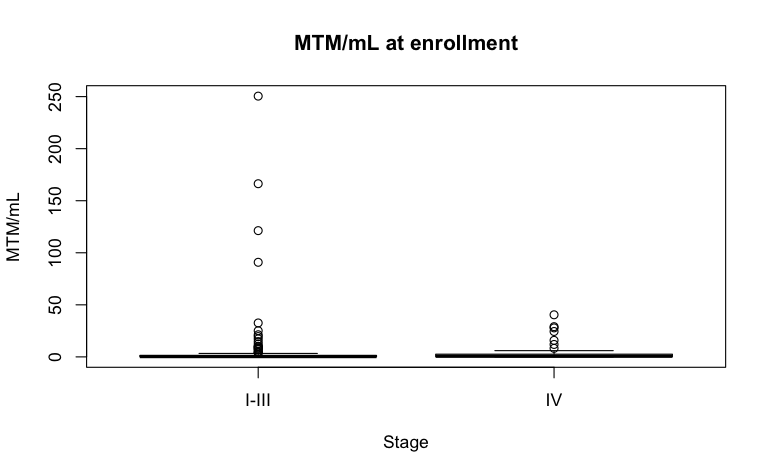

```r
circ_data$Stage.Final <- factor(circ_data$Stage.Final, levels = c("I-III", "IV"))
boxplot(p_AltBaselineMTM~Stage.Final, data=circ_data, main="MTM/mL at enrollment", xlab="Stage", ylab="MTM/mL", col="white",border="black")
```

```r
m1<-wilcox.test(p_AltBaselineMTM ~ Stage.Final, data=circ_data, na.rm=TRUE, exact=FALSE, conf.int=TRUE)
print(m1)
```

```
    Wilcoxon rank sum test with continuity correction

data:  p_AltBaselineMTM by Stage.Final
W = 4740, p-value = 0.02394
alternative hypothesis: true location shift is not equal to 0
95 percent confidence interval:
 -0.41562942 -0.01469699
sample estimates:
difference in location
            -0.1351274
```

#DFS1 by TAS vs Placebo - All stages & stratified for Stage & ctDNA 1mo post-surgery

```r
rm(list=ls())
setwd("~/Downloads")
circ_data <- read.csv("Altair 20240729 Dataset.csv")
circ_datadf <- as.data.frame(circ_data)

survfit(Surv(time = circ_data$DFS.months, event = circ_data$p_evtDFS1b)~altair.Arm, data = circ_data)
```

```
Call: survfit(formula = Surv(time = circ_data$DFS.months, event = circ_data$p_evtDFS1b) ~
    altair.Arm, data = circ_data)

                          n events median 0.95LCL 0.95UCL
altair.Arm=Control      121     99   5.55    4.17    7.33
altair.Arm=Experimental 122     99   9.30    7.92   10.84
```

```r
event_summary <- circ_data %>%
  group_by(altair.Arm) %>%
  summarise(
    Total = n(),
    Events = sum(p_evtDFS1b),
    Fraction = Events / n(),
    Percentage = (Events / n()) * 100
  )
print(event_summary)
```

```
# A tibble: 2 × 5
  altair.Arm   Total Events Fraction Percentage
  <chr>        <int>  <int>    <dbl>      <dbl>
1 Control        121     99    0.818       81.8
2 Experimental   122     99    0.811       81.1
```

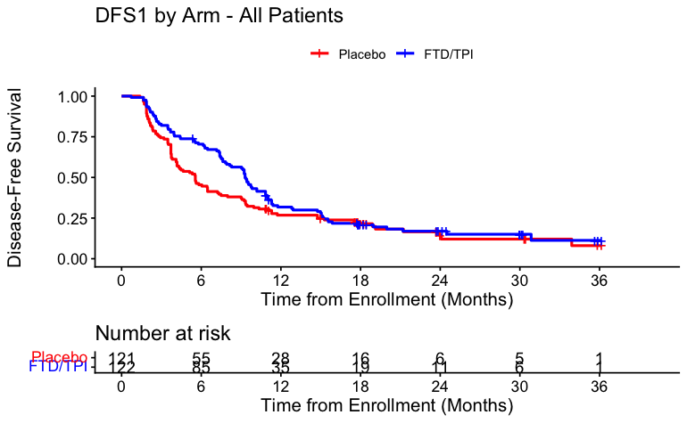

```r
surv_object <-Surv(time = circ_data$DFS.months, event = circ_data$p_evtDFS1b)
KM_curve <- survfit(surv_object ~ altair.Arm, data = circ_data,conf.int=0.95,conf.type="log-log")
ggsurvplot(KM_curve, data = circ_data, pval = FALSE, conf.int = FALSE, risk.table = TRUE, break.time.by=6, palette=c("red","blue"), title="DFS1 by Arm - All Patients", ylab= "Disease-Free Survival", xlab="Time from Enrollment (Months)", legend.labs=c("Placebo", "FTD/TPI"), legend.title="")
```

```r
summary(KM_curve, times= c(6, 12, 18, 24))
```

```
Call: survfit(formula = surv_object ~ altair.Arm, data = circ_data,
    conf.int = 0.95, conf.type = "log-log")

                altair.Arm=Control
 time n.risk n.event survival std.err lower 95% CI upper 95% CI
    6     55      66    0.455  0.0453       0.3642        0.540
   12     28      22    0.268  0.0408       0.1916        0.350
   18     16       5    0.215  0.0391       0.1443        0.296
   24      6       4    0.145  0.0394       0.0785        0.231

                altair.Arm=Experimental
 time n.risk n.event survival std.err lower 95% CI upper 95% CI
    6     85      36    0.705  0.0413        0.615        0.777
   12     35      46    0.318  0.0428        0.236        0.402
   18     19      12    0.208  0.0380        0.139        0.287
   24     11       3    0.169  0.0370        0.104        0.248
```

```r
circ_data$altair.Arm <- factor(circ_data$altair.Arm, levels=c("Control","Experimental"), labels = c("Placebo", "FTD/TPI"))
circ_data$Disease.Stage <- factor(circ_data$Disease.Stage, levels=c("Stage II or lower","StageIII", "M1"))
circ_data$ctDNA1mo <- factor(circ_data$ctDNA1mo, levels=c("NEGATIVE","POSITIVE"), labels = c("Negative", "Positive"))
cox_fit_stratified <- coxph(surv_object ~ altair.Arm + strata(Disease.Stage) + strata(ctDNA1mo), data = circ_data)
summary(cox_fit_stratified)
```

```
Call:
coxph(formula = surv_object ~ altair.Arm + strata(Disease.Stage) +
    strata(ctDNA1mo), data = circ_data)

  n= 243, number of events= 198

                     coef exp(coef) se(coef)      z Pr(>|z|)
altair.ArmFTD/TPI -0.2337    0.7916   0.1448 -1.614    0.107

                  exp(coef) exp(-coef) lower .95 upper .95
altair.ArmFTD/TPI    0.7916      1.263     0.596     1.051

Concordance= 0.555  (se = 0.021 )
Likelihood ratio test= 2.6  on 1 df,   p=0.1
Wald test            = 2.6  on 1 df,   p=0.1
Score (logrank) test = 2.61  on 1 df,   p=0.1
```

```r
# Extract values for HR, 95% CI, and p-value
cox_fit_summary_stratified <- summary(cox_fit_stratified)
HR_stratified <- cox_fit_summary_stratified$coefficients[2]
lower_CI_stratified <- cox_fit_summary_stratified$conf.int[3]
upper_CI_stratified <- cox_fit_summary_stratified$conf.int[4]
p_value_stratified <- cox_fit_summary_stratified$coefficients[5]
label_text_stratified <- paste0("HR = ", round(HR_stratified, 2),
                                " (", round(lower_CI_stratified, 2), "-",
                                round(upper_CI_stratified, 2), "); p = ",
                                round(p_value_stratified, 3))
print(label_text_stratified)
```

```
[1] "HR = 0.79 (0.6-1.05); p = 0.107"
```

#DFS1 by TAS vs Placebo - Stage I-III

```r
rm(list=ls())
setwd("~/Downloads")
circ_data <- read.csv("Altair 20240729 Dataset.csv")
circ_data <- circ_data[!(circ_data$StageA.alt %in% c("IV")),]
circ_datadf <- as.data.frame(circ_data)

survfit(Surv(time = circ_data$DFS.months, event = circ_data$p_evtDFS1b)~altair.Arm, data = circ_data)
```

```
Call: survfit(formula = Surv(time = circ_data$DFS.months, event = circ_data$p_evtDFS1b) ~
    altair.Arm, data = circ_data)

                         n events median 0.95LCL 0.95UCL
altair.Arm=Control      89     67   6.05    4.63    9.23
altair.Arm=Experimental 88     68   9.27    7.62   10.97
```

```r
event_summary <- circ_data %>%
  group_by(altair.Arm) %>%
  summarise(
    Total = n(),
    Events = sum(p_evtDFS1b),
    Fraction = Events / n(),
    Percentage = (Events / n()) * 100
  )
print(event_summary)
```

```
# A tibble: 2 × 5
  altair.Arm   Total Events Fraction Percentage
  <chr>        <int>  <int>    <dbl>      <dbl>
1 Control         89     67    0.753       75.3
2 Experimental    88     68    0.773       77.3
```

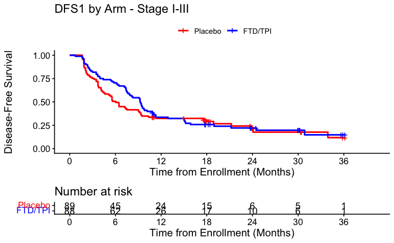

```r
surv_object <-Surv(time = circ_data$DFS.months, event = circ_data$p_evtDFS1b)
KM_curve <- survfit(surv_object ~ altair.Arm, data = circ_data,conf.int=0.95,conf.type="log-log")
ggsurvplot(KM_curve, data = circ_data, pval = FALSE, conf.int = FALSE, risk.table = TRUE, break.time.by=6, palette=c("red","blue"), title="DFS1 by Arm - Stage I-III", ylab= "Disease-Free Survival", xlab="Time from Enrollment (Months)", legend.labs=c("Placebo", "FTD/TPI"), legend.title="")
```

```r
summary(KM_curve, times= c(6, 12, 18, 24))
```

```
Call: survfit(formula = surv_object ~ altair.Arm, data = circ_data,
    conf.int = 0.95, conf.type = "log-log")

                altair.Arm=Control
 time n.risk n.event survival std.err lower 95% CI upper 95% CI
    6     45      44    0.506  0.0530        0.398        0.604
   12     24      16    0.324  0.0499        0.229        0.422
   18     15       2    0.291  0.0500        0.197        0.391
   24      6       3    0.212  0.0537        0.118        0.324

                altair.Arm=Experimental
 time n.risk n.event survival std.err lower 95% CI upper 95% CI
    6     62      26    0.705  0.0486        0.597        0.788
   12     26      32    0.336  0.0509        0.238        0.435
   18     17       6    0.258  0.0480        0.170        0.355
   24     10       2    0.221  0.0477        0.136        0.320
```

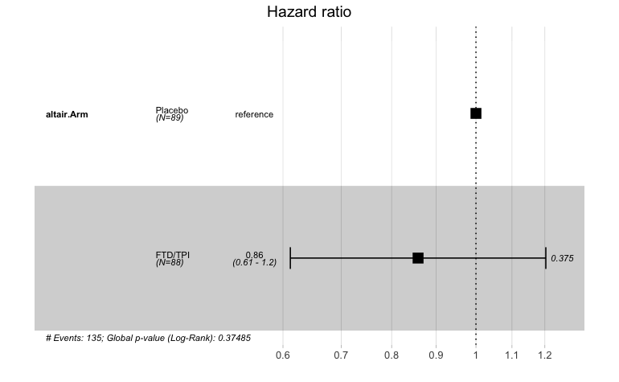

```r
circ_data$altair.Arm <- factor(circ_data$altair.Arm, levels=c("Control","Experimental"), labels = c("Placebo", "FTD/TPI"))
cox_fit <- coxph(surv_object ~ altair.Arm, data=circ_data)
ggforest(cox_fit,data = circ_data)
```

```r
summary(cox_fit)
```

```
Call:
coxph(formula = surv_object ~ altair.Arm, data = circ_data)

  n= 177, number of events= 135

                     coef exp(coef) se(coef)      z Pr(>|z|)
altair.ArmFTD/TPI -0.1532    0.8580   0.1725 -0.888    0.375

                  exp(coef) exp(-coef) lower .95 upper .95
altair.ArmFTD/TPI     0.858      1.166    0.6118     1.203

Concordance= 0.537  (se = 0.023 )
Likelihood ratio test= 0.79  on 1 df,   p=0.4
Wald test            = 0.79  on 1 df,   p=0.4
Score (logrank) test = 0.79  on 1 df,   p=0.4
```

```r
cox_fit_summary <- summary(cox_fit)

# Extract values for HR, 95% CI, and p-value
HR <- cox_fit_summary$coefficients[2]
lower_CI <- cox_fit_summary$conf.int[3]
upper_CI <- cox_fit_summary$conf.int[4]
p_value <- cox_fit_summary$coefficients[5]
label_text <- paste0("HR = ", round(HR, 2), " (", round(lower_CI, 2), "-", round(upper_CI, 2), "); p = ", round(p_value, 3))
print(label_text)
```

```
[1] "HR = 0.86 (0.61-1.2); p = 0.375"
```

#DFS1 by TAS vs Placebo - Stage IV

```r
rm(list=ls())
setwd("~/Downloads")
circ_data <- read.csv("Altair 20240729 Dataset.csv")
circ_data <- circ_data[!(circ_data$StageA.alt %in% c("I", "II", "III")),]
circ_datadf <- as.data.frame(circ_data)

survfit(Surv(time = circ_data$DFS.months, event = circ_data$p_evtDFS1b)~altair.Arm, data = circ_data)
```

```
Call: survfit(formula = Surv(time = circ_data$DFS.months, event = circ_data$p_evtDFS1b) ~
    altair.Arm, data = circ_data)

                         n events median 0.95LCL 0.95UCL
altair.Arm=Control      32     32   3.96    3.71    7.98
altair.Arm=Experimental 34     31   9.76    7.62   11.76
```

```r
event_summary <- circ_data %>%
  group_by(altair.Arm) %>%
  summarise(
    Total = n(),
    Events = sum(p_evtDFS1b),
    Fraction = Events / n(),
    Percentage = (Events / n()) * 100
  )
print(event_summary)
```

```
# A tibble: 2 × 5
  altair.Arm   Total Events Fraction Percentage
  <chr>        <int>  <int>    <dbl>      <dbl>
1 Control         32     32    1          100
2 Experimental    34     31    0.912       91.2
```

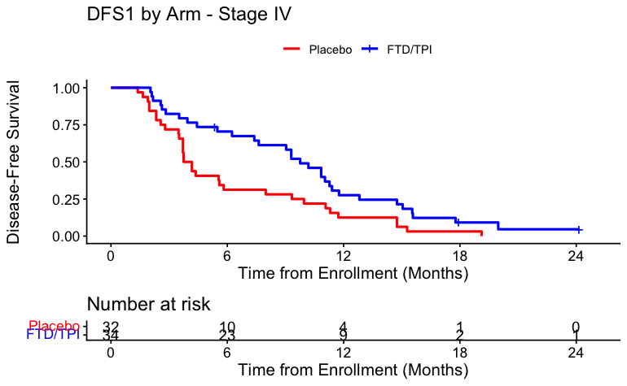

```r
surv_object <-Surv(time = circ_data$DFS.months, event = circ_data$p_evtDFS1b)
KM_curve <- survfit(surv_object ~ altair.Arm, data = circ_data,conf.int=0.95,conf.type="log-log")
ggsurvplot(KM_curve, data = circ_data, pval = FALSE, conf.int = FALSE, risk.table = TRUE, break.time.by=6, palette=c("red","blue"), title="DFS1 by Arm - Stage IV", ylab= "Disease-Free Survival", xlab="Time from Enrollment (Months)", legend.labs=c("Placebo", "FTD/TPI"), legend.title="")
```

```r
summary(KM_curve, times= c(6, 12, 18, 24))
```

```
Call: survfit(formula = surv_object ~ altair.Arm, data = circ_data,
    conf.int = 0.95, conf.type = "log-log")

                altair.Arm=Control
 time n.risk n.event survival std.err lower 95% CI upper 95% CI
    6     10      22   0.3125  0.0819      0.16376        0.473
   12      4       6   0.1250  0.0585      0.03950        0.262
   18      1       3   0.0312  0.0308      0.00237        0.137

                altair.Arm=Experimental
 time n.risk n.event survival std.err lower 95% CI upper 95% CI
    6     23      10   0.7047  0.0785      0.52049        0.829
   12      9      14   0.2757  0.0780      0.13790        0.433
   18      2       6   0.0919  0.0505      0.02355        0.219
   24      1       1   0.0460  0.0412      0.00431        0.175
```

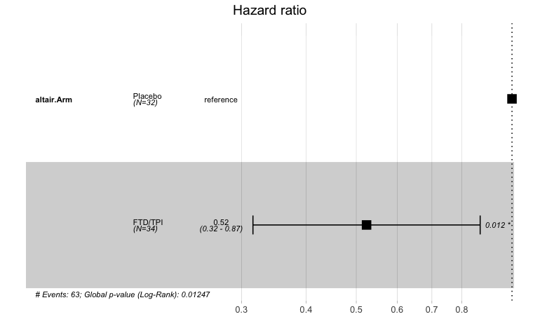

```r
circ_data$altair.Arm <- factor(circ_data$altair.Arm, levels=c("Control","Experimental"), labels = c("Placebo", "FTD/TPI"))
cox_fit <- coxph(surv_object ~ altair.Arm, data=circ_data)
ggforest(cox_fit,data = circ_data)
```

```r
summary(cox_fit)
```

```
Call:
coxph(formula = surv_object ~ altair.Arm, data = circ_data)

  n= 66, number of events= 63

                     coef exp(coef) se(coef)      z Pr(>|z|)
altair.ArmFTD/TPI -0.6474    0.5234   0.2580 -2.509   0.0121 *
---
Signif. codes:  0 ‘***’ 0.001 ‘**’ 0.01 ‘*’ 0.05 ‘.’ 0.1 ‘ ’ 1

                  exp(coef) exp(-coef) lower .95 upper .95
altair.ArmFTD/TPI    0.5234      1.911    0.3157    0.8679

Concordance= 0.596  (se = 0.034 )
Likelihood ratio test= 6.24  on 1 df,   p=0.01
Wald test            = 6.3  on 1 df,   p=0.01
Score (logrank) test = 6.5  on 1 df,   p=0.01
```

```r
cox_fit_summary <- summary(cox_fit)

# Extract values for HR, 95% CI, and p-value
HR <- cox_fit_summary$coefficients[2]
lower_CI <- cox_fit_summary$conf.int[3]
upper_CI <- cox_fit_summary$conf.int[4]
p_value <- cox_fit_summary$coefficients[5]
label_text <- paste0("HR = ", round(HR, 2), " (", round(lower_CI, 2), "-", round(upper_CI, 2), "); p = ", round(p_value, 3))
print(label_text)
```

```
[1] "HR = 0.52 (0.32-0.87); p = 0.012"
```

#DFS1 by TAS vs Placebo - ctDNA positive post-surgery

```r
rm(list=ls())
setwd("~/Downloads")
circ_data <- read.csv("Altair 20240729 Dataset.csv")
circ_data <- circ_data[circ_data$ctDNA1mo == "POSITIVE",]
circ_data <- subset(circ_data, !is.na(p_MRD))
circ_datadf <- as.data.frame(circ_data)

survfit(Surv(time = circ_data$DFS.months, event = circ_data$p_evtDFS1b)~altair.Arm, data = circ_data)
```

```
Call: survfit(formula = Surv(time = circ_data$DFS.months, event = circ_data$p_evtDFS1b) ~
    altair.Arm, data = circ_data)

                         n events median 0.95LCL 0.95UCL
altair.Arm=Control      65     58   4.17    3.71    6.47
altair.Arm=Experimental 65     55   7.92    7.16   10.84
```

```r
event_summary <- circ_data %>%
  group_by(altair.Arm) %>%
  summarise(
    Total = n(),
    Events = sum(p_evtDFS1b),
    Fraction = Events / n(),
    Percentage = (Events / n()) * 100
  )
print(event_summary)
```

```
# A tibble: 2 × 5
  altair.Arm   Total Events Fraction Percentage
  <chr>        <int>  <int>    <dbl>      <dbl>
1 Control         65     58    0.892       89.2
2 Experimental    65     55    0.846       84.6
```

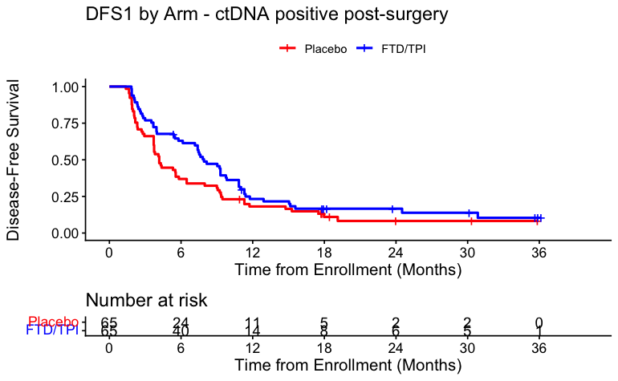

```r
surv_object <-Surv(time = circ_data$DFS.months, event = circ_data$p_evtDFS1b)
KM_curve <- survfit(surv_object ~ altair.Arm, data = circ_data,conf.int=0.95,conf.type="log-log")
ggsurvplot(KM_curve, data = circ_data, pval = FALSE, conf.int = FALSE, risk.table = TRUE, break.time.by=6, palette=c("red","blue"), title="DFS1 by Arm - ctDNA positive post-surgery", ylab= "Disease-Free Survival", xlab="Time from Enrollment (Months)", legend.labs=c("Placebo", "FTD/TPI"), legend.title="")
```

```r
summary(KM_curve, times= c(6, 12, 18, 24))
```

```
Call: survfit(formula = surv_object ~ altair.Arm, data = circ_data,
    conf.int = 0.95, conf.type = "log-log")

                altair.Arm=Control
 time n.risk n.event survival std.err lower 95% CI upper 95% CI
    6     24      41   0.3692  0.0599       0.2540        0.485
   12     11      12   0.1813  0.0482       0.0985        0.284
   18      5       4   0.1099  0.0408       0.0464        0.204
   24      2       1   0.0824  0.0388       0.0270        0.178

                altair.Arm=Experimental
 time n.risk n.event survival std.err lower 95% CI upper 95% CI
    6     40      24    0.630  0.0600       0.5002        0.734
   12     14      25    0.233  0.0534       0.1374        0.343
   18      8       4    0.166  0.0473       0.0863        0.269
   24      6       0    0.166  0.0473       0.0863        0.269
```

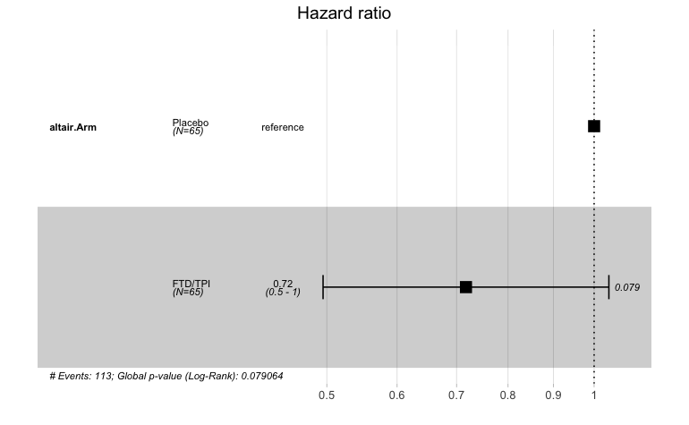

```r
circ_data$altair.Arm <- factor(circ_data$altair.Arm, levels=c("Control","Experimental"), labels = c("Placebo", "FTD/TPI"))
cox_fit <- coxph(surv_object ~ altair.Arm, data=circ_data)
ggforest(cox_fit,data = circ_data)
```

```r
summary(cox_fit)
```

```
Call:
coxph(formula = surv_object ~ altair.Arm, data = circ_data)

  n= 130, number of events= 113

                     coef exp(coef) se(coef)      z Pr(>|z|)
altair.ArmFTD/TPI -0.3323    0.7173   0.1891 -1.757   0.0789 .
---
Signif. codes:  0 ‘***’ 0.001 ‘**’ 0.01 ‘*’ 0.05 ‘.’ 0.1 ‘ ’ 1

                  exp(coef) exp(-coef) lower .95 upper .95
altair.ArmFTD/TPI    0.7173      1.394    0.4952     1.039

Concordance= 0.56  (se = 0.026 )
Likelihood ratio test= 3.08  on 1 df,   p=0.08
Wald test            = 3.09  on 1 df,   p=0.08
Score (logrank) test = 3.12  on 1 df,   p=0.08
```

```r
cox_fit_summary <- summary(cox_fit)

# Extract values for HR, 95% CI, and p-value
HR <- cox_fit_summary$coefficients[2]
lower_CI <- cox_fit_summary$conf.int[3]
upper_CI <- cox_fit_summary$conf.int[4]
p_value <- cox_fit_summary$coefficients[5]
label_text <- paste0("HR = ", round(HR, 2), " (", round(lower_CI, 2), "-", round(upper_CI, 2), "); p = ", round(p_value, 3))
print(label_text)
```

```
[1] "HR = 0.72 (0.5-1.04); p = 0.079"
```

```r
#Fisher test for DFS percentages at 6, 12, 18 and 24 months
dfs_times <- c(6, 12, 18, 24)
p_values <- sapply(dfs_times, function(time) {
  neg_count <- sum(circ_data$altair.Arm == "FTD/TPI" & circ_data$DFS.months >= time & circ_data$p_evtDFS1b == 0)
  pos_count <- sum(circ_data$altair.Arm == "Placebo" & circ_data$DFS.months >= time & circ_data$p_evtDFS1b == 0)
  neg_total <- sum(circ_data$altair.Arm == "FTD/TPI")
  pos_total <- sum(circ_data$altair.Arm == "Placebo")

  neg_surv <- neg_total - sum(circ_data$altair.Arm == "FTD/TPI" & circ_data$p_evtDFS1b == 1 & circ_data$DFS.months < time)
  pos_surv <- pos_total - sum(circ_data$altair.Arm == "Placebo" & circ_data$p_evtDFS1b == 1 & circ_data$DFS.months < time)

  surv_matrix <- matrix(c(neg_surv, pos_surv, neg_total - neg_surv, pos_total - pos_surv), nrow = 2)
  test_result <- fisher.test(surv_matrix)
  return(test_result$p.value)
})
names(p_values) <- paste0("p-value at ", dfs_times, " months")
print(p_values)
```

```
 p-value at 6 months p-value at 12 months p-value at 18 months p-value at 24 months
         0.004815238          0.522656471          0.466593017          0.320823902
```

#DFS1 by TAS vs Placebo - ctDNA negative post-surgery

```r
rm(list=ls())
setwd("~/Downloads")
circ_data <- read.csv("Altair 20240729 Dataset.csv")
circ_data <- circ_data[circ_data$ctDNA1mo == "NEGATIVE",]
circ_data <- subset(circ_data, !is.na(ctDNA1mo))
circ_datadf <- as.data.frame(circ_data)

survfit(Surv(time = circ_data$DFS.months, event = circ_data$p_evtDFS1b)~altair.Arm, data = circ_data)
```

```
Call: survfit(formula = Surv(time = circ_data$DFS.months, event = circ_data$p_evtDFS1b) ~
    altair.Arm, data = circ_data)

                         n events median 0.95LCL 0.95UCL
altair.Arm=Control      56     41   6.85    5.55    18.9
altair.Arm=Experimental 57     44  10.18    9.23    15.0
```

```r
event_summary <- circ_data %>%
  group_by(altair.Arm) %>%
  summarise(
    Total = n(),
    Events = sum(p_evtDFS1b),
    Fraction = Events / n(),
    Percentage = (Events / n()) * 100
  )
print(event_summary)
```

```
# A tibble: 2 × 5
  altair.Arm   Total Events Fraction Percentage
  <chr>        <int>  <int>    <dbl>      <dbl>
1 Control         56     41    0.732       73.2
2 Experimental    57     44    0.772       77.2
```

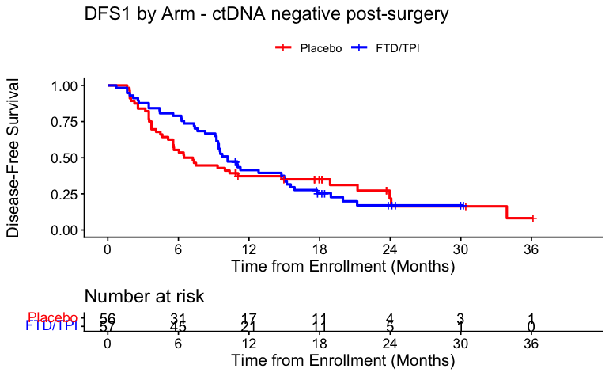

```r
surv_object <-Surv(time = circ_data$DFS.months, event = circ_data$p_evtDFS1b)
KM_curve <- survfit(surv_object ~ altair.Arm, data = circ_data,conf.int=0.95,conf.type="log-log")
ggsurvplot(KM_curve, data = circ_data, pval = FALSE, conf.int = FALSE, risk.table = TRUE, break.time.by=6, palette=c("red","blue"), title="DFS1 by Arm - ctDNA negative post-surgery", ylab= "Disease-Free Survival", xlab="Time from Enrollment (Months)", legend.labs=c("Placebo", "FTD/TPI"), legend.title="")
```

```r
summary(KM_curve, times= c(6, 12, 18, 24))
```

```
Call: survfit(formula = surv_object ~ altair.Arm, data = circ_data,
    conf.int = 0.95, conf.type = "log-log")

                altair.Arm=Control
 time n.risk n.event survival std.err lower 95% CI upper 95% CI
    6     31      25    0.554  0.0664       0.4147        0.672
   12     17      10    0.372  0.0650       0.2472        0.497
   18     11       1    0.350  0.0648       0.2272        0.476
   24      4       3    0.218  0.0742       0.0943        0.374

                altair.Arm=Experimental
 time n.risk n.event survival std.err lower 95% CI upper 95% CI
    6     45      12    0.789  0.0540       0.6592        0.875
   12     21      21    0.414  0.0661       0.2848        0.539
   18     11       8    0.255  0.0602       0.1471        0.378
   24      5       3    0.170  0.0567       0.0771        0.294
```

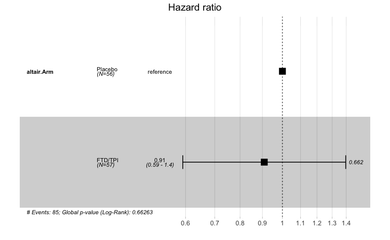

```r
circ_data$altair.Arm <- factor(circ_data$altair.Arm, levels=c("Control","Experimental"), labels = c("Placebo", "FTD/TPI"))
cox_fit <- coxph(surv_object ~ altair.Arm, data=circ_data)
ggforest(cox_fit,data = circ_data)
```

```r
summary(cox_fit)
```

```
Call:
coxph(formula = surv_object ~ altair.Arm, data = circ_data)

  n= 113, number of events= 85

                      coef exp(coef) se(coef)      z Pr(>|z|)
altair.ArmFTD/TPI -0.09568   0.90875  0.21911 -0.437    0.662

                  exp(coef) exp(-coef) lower .95 upper .95
altair.ArmFTD/TPI    0.9088        1.1    0.5915     1.396

Concordance= 0.538  (se = 0.03 )
Likelihood ratio test= 0.19  on 1 df,   p=0.7
Wald test            = 0.19  on 1 df,   p=0.7
Score (logrank) test = 0.19  on 1 df,   p=0.7
```

```r
cox_fit_summary <- summary(cox_fit)

# Extract values for HR, 95% CI, and p-value
HR <- cox_fit_summary$coefficients[2]
lower_CI <- cox_fit_summary$conf.int[3]
upper_CI <- cox_fit_summary$conf.int[4]
p_value <- cox_fit_summary$coefficients[5]
label_text <- paste0("HR = ", round(HR, 2), " (", round(lower_CI, 2), "-", round(upper_CI, 2), "); p = ", round(p_value, 3))
print(label_text)
```

```
[1] "HR = 0.91 (0.59-1.4); p = 0.662"
```

#DFS2 by TAS vs Placebo - All stages

```r
rm(list=ls())
setwd("~/Downloads")
circ_data <- read.csv("Altair 20240729 Dataset.csv")
circ_datadf <- as.data.frame(circ_data)

survfit(Surv(time = circ_data$DFS2.months, event = circ_data$p_evtDFS2)~altair.Arm, data = circ_data)
```

```
Call: survfit(formula = Surv(time = circ_data$DFS2.months, event = circ_data$p_evtDFS2) ~
    altair.Arm, data = circ_data)

                          n events median 0.95LCL 0.95UCL
altair.Arm=Control      121    100   5.55    4.17    7.33
altair.Arm=Experimental 122     99   9.30    7.92   10.84
```

```r
event_summary <- circ_data %>%
  group_by(altair.Arm) %>%
  summarise(
    Total = n(),
    Events = sum(p_evtDFS2),
    Fraction = Events / n(),
    Percentage = (Events / n()) * 100
  )
print(event_summary)
```

```
# A tibble: 2 × 5
  altair.Arm   Total Events Fraction Percentage
  <chr>        <int>  <int>    <dbl>      <dbl>
1 Control        121    100    0.826       82.6
2 Experimental   122     99    0.811       81.1
```

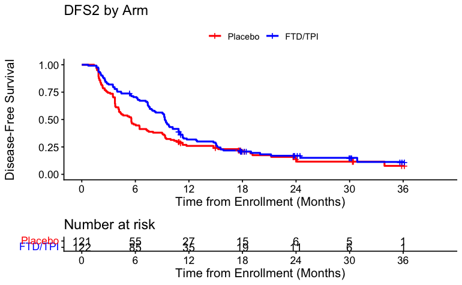

```r
surv_object <-Surv(time = circ_data$DFS2.months, event = circ_data$p_evtDFS2)
KM_curve <- survfit(surv_object ~ altair.Arm, data = circ_data,conf.int=0.95,conf.type="log-log")
ggsurvplot(KM_curve, data = circ_data, pval = FALSE, conf.int = FALSE, risk.table = TRUE, break.time.by=6, palette=c("red","blue"), title="DFS2 by Arm", ylab= "Disease-Free Survival", xlab="Time from Enrollment (Months)", legend.labs=c("Placebo", "FTD/TPI"), legend.title="")
```

```r
summary(KM_curve, times= c(6, 12, 18, 24))
```

```
Call: survfit(formula = surv_object ~ altair.Arm, data = circ_data,
    conf.int = 0.95, conf.type = "log-log")

                altair.Arm=Control
 time n.risk n.event survival std.err lower 95% CI upper 95% CI
    6     55      66    0.455  0.0453       0.3642        0.540
   12     27      23    0.259  0.0404       0.1842        0.341
   18     15       5    0.206  0.0386       0.1366        0.286
   24      6       4    0.139  0.0383       0.0746        0.223

                altair.Arm=Experimental
 time n.risk n.event survival std.err lower 95% CI upper 95% CI
    6     85      36    0.705  0.0413        0.615        0.777
   12     35      46    0.318  0.0428        0.236        0.402
   18     19      12    0.208  0.0380        0.139        0.287
   24     11       3    0.169  0.0370        0.104        0.248
```

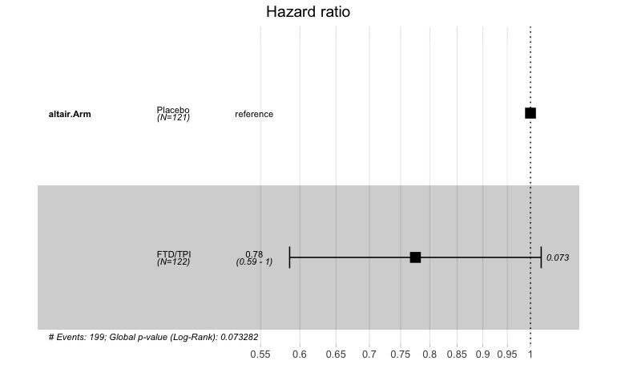

```r
circ_data$altair.Arm <- factor(circ_data$altair.Arm, levels=c("Control","Experimental"), labels = c("Placebo", "FTD/TPI"))
cox_fit <- coxph(surv_object ~ altair.Arm, data=circ_data)
ggforest(cox_fit,data = circ_data)
```

```r
summary(cox_fit)
```

```
Call:
coxph(formula = surv_object ~ altair.Arm, data = circ_data)

  n= 243, number of events= 199

                     coef exp(coef) se(coef)      z Pr(>|z|)
altair.ArmFTD/TPI -0.2549    0.7750   0.1421 -1.793    0.073 .
---
Signif. codes:  0 ‘***’ 0.001 ‘**’ 0.01 ‘*’ 0.05 ‘.’ 0.1 ‘ ’ 1

                  exp(coef) exp(-coef) lower .95 upper .95
altair.ArmFTD/TPI     0.775       1.29    0.5866     1.024

Concordance= 0.552  (se = 0.019 )
Likelihood ratio test= 3.21  on 1 df,   p=0.07
Wald test            = 3.22  on 1 df,   p=0.07
Score (logrank) test = 3.23  on 1 df,   p=0.07
```

```r
cox_fit_summary <- summary(cox_fit)

# Extract values for HR, 95% CI, and p-value
HR <- cox_fit_summary$coefficients[2]
lower_CI <- cox_fit_summary$conf.int[3]
upper_CI <- cox_fit_summary$conf.int[4]
p_value <- cox_fit_summary$coefficients[5]
label_text <- paste0("HR = ", round(HR, 2), " (", round(lower_CI, 2), "-", round(upper_CI, 2), "); p = ", round(p_value, 3))
print(label_text)
```

```
[1] "HR = 0.78 (0.59-1.02); p = 0.073"
```

#DFS1 by ctDNA MRD enrollment timepoint TAS vs Placebo

```r
rm(list=ls())
setwd("~/Downloads")
circ_data <- read.csv("Altair 20240729 Dataset.csv")
circ_data <- circ_data[circ_data$p_AltBaselineWin=="MRD",]
circ_datadf <- as.data.frame(circ_data)

survfit(Surv(time = circ_data$DFS.months, event = circ_data$p_evtDFS1b)~altair.Arm, data = circ_data)
```

```
Call: survfit(formula = Surv(time = circ_data$DFS.months, event = circ_data$p_evtDFS1b) ~
    altair.Arm, data = circ_data)

                         n events median 0.95LCL 0.95UCL
altair.Arm=Control      30     26   4.17    3.71    7.98
altair.Arm=Experimental 28     22   7.77    5.39   11.30
```

```r
event_summary <- circ_data %>%
  group_by(altair.Arm) %>%
  summarise(
    Total = n(),
    Events = sum(p_evtDFS1b),
    Fraction = Events / n(),
    Percentage = (Events / n()) * 100
  )
print(event_summary)
```

```
# A tibble: 2 × 5
  altair.Arm   Total Events Fraction Percentage
  <chr>        <int>  <int>    <dbl>      <dbl>
1 Control         30     26    0.867       86.7
2 Experimental    28     22    0.786       78.6
```

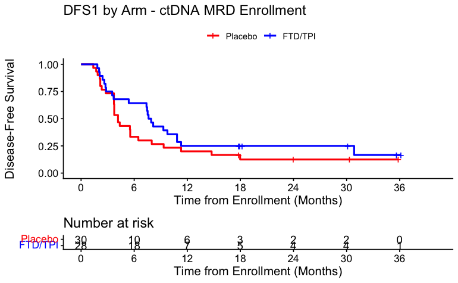

```r
surv_object <-Surv(time = circ_data$DFS.months, event = circ_data$p_evtDFS1b)
KM_curve <- survfit(surv_object ~ altair.Arm, data = circ_data,conf.int=0.95,conf.type="log-log")
ggsurvplot(KM_curve, data = circ_data, pval = FALSE, conf.int = FALSE, risk.table = TRUE, break.time.by=6, palette=c("red","blue"), title="DFS1 by Arm - ctDNA MRD Enrollment", ylab= "Disease-Free Survival", xlab="Time from Enrollment (Months)", legend.labs=c("Placebo", "FTD/TPI"), legend.title="")
```

```r
summary(KM_curve, times= c(6, 12, 18, 24))
```

```
Call: survfit(formula = surv_object ~ altair.Arm, data = circ_data,
    conf.int = 0.95, conf.type = "log-log")

                altair.Arm=Control
 time n.risk n.event survival std.err lower 95% CI upper 95% CI
    6     10      20    0.333  0.0861       0.1753        0.500
   12      6       4    0.200  0.0730       0.0812        0.356
   18      3       2    0.125  0.0625       0.0357        0.273
   24      2       0    0.125  0.0625       0.0357        0.273

                altair.Arm=Experimental
 time n.risk n.event survival std.err lower 95% CI upper 95% CI
    6     18      10    0.643  0.0906        0.438        0.789
   12      7      11    0.250  0.0818        0.111        0.418
   18      5       0    0.250  0.0818        0.111        0.418
   24      4       0    0.250  0.0818        0.111        0.418
```

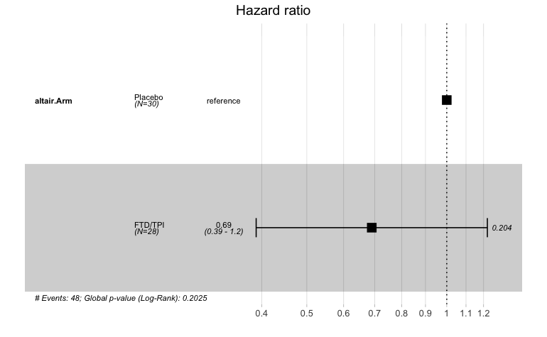

```r
circ_data$altair.Arm <- factor(circ_data$altair.Arm, levels=c("Control","Experimental"), labels = c("Placebo", "FTD/TPI"))
cox_fit <- coxph(surv_object ~ altair.Arm, data=circ_data)
ggforest(cox_fit,data = circ_data)
```

```r
summary(cox_fit)
```

```
Call:
coxph(formula = surv_object ~ altair.Arm, data = circ_data)

  n= 58, number of events= 48

                     coef exp(coef) se(coef)      z Pr(>|z|)
altair.ArmFTD/TPI -0.3714    0.6897   0.2921 -1.271    0.204

                  exp(coef) exp(-coef) lower .95 upper .95
altair.ArmFTD/TPI    0.6897       1.45    0.3891     1.223

Concordance= 0.555  (se = 0.04 )
Likelihood ratio test= 1.62  on 1 df,   p=0.2
Wald test            = 1.62  on 1 df,   p=0.2
Score (logrank) test = 1.63  on 1 df,   p=0.2
```

```r
cox_fit_summary <- summary(cox_fit)

# Extract values for HR, 95% CI, and p-value
HR <- cox_fit_summary$coefficients[2]
lower_CI <- cox_fit_summary$conf.int[3]
upper_CI <- cox_fit_summary$conf.int[4]
p_value <- cox_fit_summary$coefficients[5]
label_text <- paste0("HR = ", round(HR, 2), " (", round(lower_CI, 2), "-", round(upper_CI, 2), "); p = ", round(p_value, 3))
print(label_text)
```

```
[1] "HR = 0.69 (0.39-1.22); p = 0.204"
```

```r
#Fisher test for DFS percentages at 6, 12, 18 and 24 months
dfs_times <- c(6, 12, 18, 24)
p_values <- sapply(dfs_times, function(time) {
  neg_count <- sum(circ_data$altair.Arm == "FTD/TPI" & circ_data$DFS.months >= time & circ_data$p_evtDFS1b == 0)
  pos_count <- sum(circ_data$altair.Arm == "Placebo" & circ_data$DFS.months >= time & circ_data$p_evtDFS1b == 0)
  neg_total <- sum(circ_data$altair.Arm == "FTD/TPI")
  pos_total <- sum(circ_data$altair.Arm == "Placebo")

  neg_surv <- neg_total - sum(circ_data$altair.Arm == "FTD/TPI" & circ_data$p_evtDFS1b == 1 & circ_data$DFS.months < time)
  pos_surv <- pos_total - sum(circ_data$altair.Arm == "Placebo" & circ_data$p_evtDFS1b == 1 & circ_data$DFS.months < time)

  surv_matrix <- matrix(c(neg_surv, pos_surv, neg_total - neg_surv, pos_total - pos_surv), nrow = 2)
  test_result <- fisher.test(surv_matrix)
  return(test_result$p.value)
})
names(p_values) <- paste0("p-value at ", dfs_times, " months")
print(p_values)
```

```
 p-value at 6 months p-value at 12 months p-value at 18 months p-value at 24 months
          0.03454285           0.75694899           0.32484791           0.32484791
```

#DFS1 by ctDNA On-treatment timepoint TAS vs Placebo

```r
rm(list=ls())
setwd("~/Downloads")
circ_data <- read.csv("Altair 20240729 Dataset.csv")
circ_data <- circ_data[circ_data$p_AltBaselineWin=="OnTreatment",]
circ_datadf <- as.data.frame(circ_data)

survfit(Surv(time = circ_data$DFS.months, event = circ_data$p_evtDFS1b)~altair.Arm, data = circ_data)
```

```
Call: survfit(formula = Surv(time = circ_data$DFS.months, event = circ_data$p_evtDFS1b) ~
    altair.Arm, data = circ_data)

                         n events median 0.95LCL 0.95UCL
altair.Arm=Control      19     16   9.07    4.30    17.5
altair.Arm=Experimental 14     13   6.64    2.99      NA
```

```r
event_summary <- circ_data %>%
  group_by(altair.Arm) %>%
  summarise(
    Total = n(),
    Events = sum(p_evtDFS1b),
    Fraction = Events / n(),
    Percentage = (Events / n()) * 100
  )
print(event_summary)
```

```
# A tibble: 2 × 5
  altair.Arm   Total Events Fraction Percentage
  <chr>        <int>  <int>    <dbl>      <dbl>
1 Control         19     16    0.842       84.2
2 Experimental    14     13    0.929       92.9
```

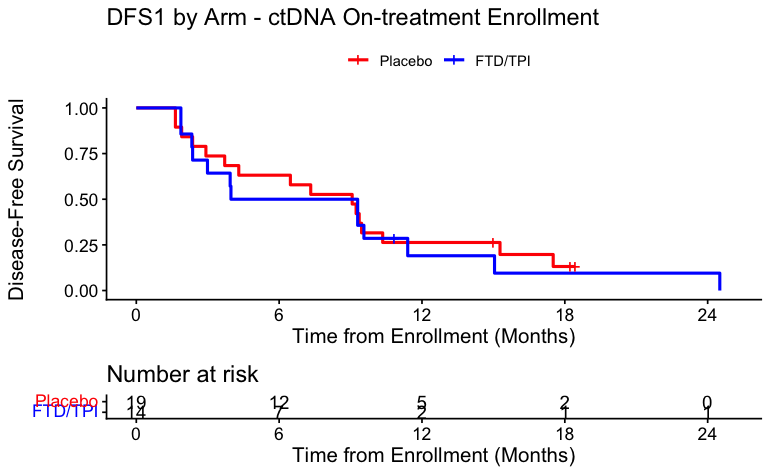

```r
surv_object <-Surv(time = circ_data$DFS.months, event = circ_data$p_evtDFS1b)
KM_curve <- survfit(surv_object ~ altair.Arm, data = circ_data,conf.int=0.95,conf.type="log-log")
ggsurvplot(KM_curve, data = circ_data, pval = FALSE, conf.int = FALSE, risk.table = TRUE, break.time.by=6, palette=c("red","blue"), title="DFS1 by Arm - ctDNA On-treatment Enrollment", ylab= "Disease-Free Survival", xlab="Time from Enrollment (Months)", legend.labs=c("Placebo", "FTD/TPI"), legend.title="")
```

```r
summary(KM_curve, times= c(6, 12, 18, 24))
```

```
Call: survfit(formula = surv_object ~ altair.Arm, data = circ_data,
    conf.int = 0.95, conf.type = "log-log")

                altair.Arm=Control
 time n.risk n.event survival std.err lower 95% CI upper 95% CI
    6     12       7    0.632  0.1107       0.3790        0.804
   12      5       7    0.263  0.1010       0.0958        0.468
   18      2       2    0.132  0.0829       0.0240        0.332

                altair.Arm=Experimental
 time n.risk n.event survival std.err lower 95% CI upper 95% CI
    6      7       7   0.5000  0.1336      0.22859        0.722
   12      2       4   0.1905  0.1119      0.03612        0.437
   18      1       1   0.0952  0.0876      0.00635        0.335
   24      1       0   0.0952  0.0876      0.00635        0.335
```

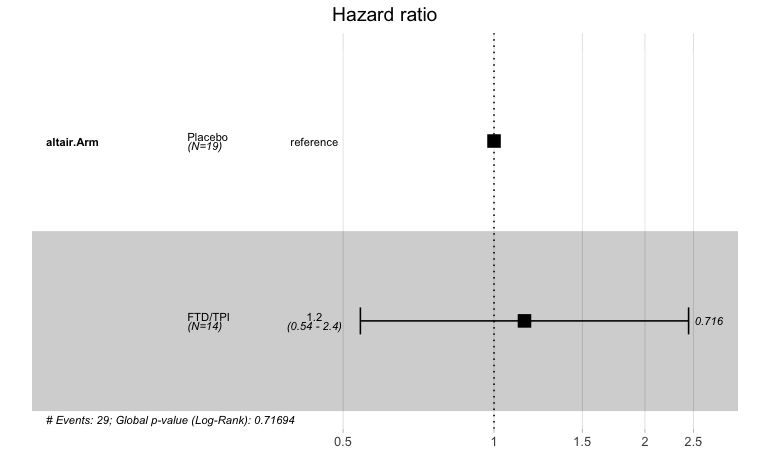

```r
circ_data$altair.Arm <- factor(circ_data$altair.Arm, levels=c("Control","Experimental"), labels = c("Placebo", "FTD/TPI"))
cox_fit <- coxph(surv_object ~ altair.Arm, data=circ_data)
ggforest(cox_fit,data = circ_data)
```

```r
summary(cox_fit)
```

```
Call:
coxph(formula = surv_object ~ altair.Arm, data = circ_data)

  n= 33, number of events= 29

                    coef exp(coef) se(coef)     z Pr(>|z|)
altair.ArmFTD/TPI 0.1399    1.1502   0.3846 0.364    0.716

                  exp(coef) exp(-coef) lower .95 upper .95
altair.ArmFTD/TPI      1.15     0.8694    0.5413     2.444

Concordance= 0.516  (se = 0.053 )
Likelihood ratio test= 0.13  on 1 df,   p=0.7
Wald test            = 0.13  on 1 df,   p=0.7
Score (logrank) test = 0.13  on 1 df,   p=0.7
```

```r
cox_fit_summary <- summary(cox_fit)

# Extract values for HR, 95% CI, and p-value
HR <- cox_fit_summary$coefficients[2]
lower_CI <- cox_fit_summary$conf.int[3]
upper_CI <- cox_fit_summary$conf.int[4]
p_value <- cox_fit_summary$coefficients[5]
label_text <- paste0("HR = ", round(HR, 2), " (", round(lower_CI, 2), "-", round(upper_CI, 2), "); p = ", round(p_value, 3))
print(label_text)
```

```
[1] "HR = 1.15 (0.54-2.44); p = 0.716"
```

```r
#Fisher test for DFS percentages at 6, 12, 18 and 24 months
dfs_times <- c(6, 12, 18, 24)
p_values <- sapply(dfs_times, function(time) {
  neg_count <- sum(circ_data$altair.Arm == "FTD/TPI" & circ_data$DFS.months >= time & circ_data$p_evtDFS1b == 0)
  pos_count <- sum(circ_data$altair.Arm == "Placebo" & circ_data$DFS.months >= time & circ_data$p_evtDFS1b == 0)
  neg_total <- sum(circ_data$altair.Arm == "FTD/TPI")
  pos_total <- sum(circ_data$altair.Arm == "Placebo")

  neg_surv <- neg_total - sum(circ_data$altair.Arm == "FTD/TPI" & circ_data$p_evtDFS1b == 1 & circ_data$DFS.months < time)
  pos_surv <- pos_total - sum(circ_data$altair.Arm == "Placebo" & circ_data$p_evtDFS1b == 1 & circ_data$DFS.months < time)

  surv_matrix <- matrix(c(neg_surv, pos_surv, neg_total - neg_surv, pos_total - pos_surv), nrow = 2)
  test_result <- fisher.test(surv_matrix)
  return(test_result$p.value)
})
names(p_values) <- paste0("p-value at ", dfs_times, " months")
print(p_values)
```

```
 p-value at 6 months p-value at 12 months p-value at 18 months p-value at 24 months
           0.4969359            1.0000000            1.0000000            1.0000000
```

#DFS1 by ctDNA Surveillance timepoint TAS vs Placebo

```r
rm(list=ls())
setwd("~/Downloads")
circ_data <- read.csv("Altair 20240729 Dataset.csv")
circ_data <- circ_data[circ_data$p_AltBaselineWin=="Surveillance",]
circ_datadf <- as.data.frame(circ_data)

survfit(Surv(time = circ_data$DFS.months, event = circ_data$p_evtDFS1b)~altair.Arm, data = circ_data)
```

```
Call: survfit(formula = Surv(time = circ_data$DFS.months, event = circ_data$p_evtDFS1b) ~
    altair.Arm, data = circ_data)

                         n events median 0.95LCL 0.95UCL
altair.Arm=Control      72     57   5.57    4.11    9.33
altair.Arm=Experimental 80     64   9.73    9.13   11.76
```

```r
event_summary <- circ_data %>%
  group_by(altair.Arm) %>%
  summarise(
    Total = n(),
    Events = sum(p_evtDFS1b),
    Fraction = Events / n(),
    Percentage = (Events / n()) * 100
  )
print(event_summary)
```

```
# A tibble: 2 × 5
  altair.Arm   Total Events Fraction Percentage
  <chr>        <int>  <int>    <dbl>      <dbl>
1 Control         72     57    0.792       79.2
2 Experimental    80     64    0.8         80
```

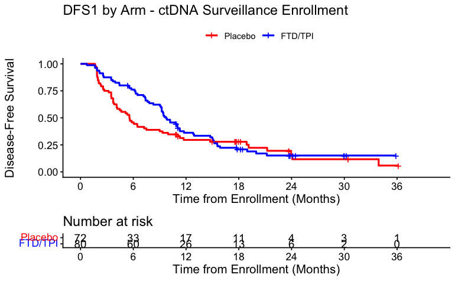

```r
surv_object <-Surv(time = circ_data$DFS.months, event = circ_data$p_evtDFS1b)
KM_curve <- survfit(surv_object ~ altair.Arm, data = circ_data,conf.int=0.95,conf.type="log-log")
ggsurvplot(KM_curve, data = circ_data, pval = FALSE, conf.int = FALSE, risk.table = TRUE, break.time.by=6, palette=c("red","blue"), title="DFS1 by Arm - ctDNA Surveillance Enrollment", ylab= "Disease-Free Survival", xlab="Time from Enrollment (Months)", legend.labs=c("Placebo", "FTD/TPI"), legend.title="")
```

```r
summary(KM_curve, times= c(6, 12, 18, 24))
```

```
Call: survfit(formula = surv_object ~ altair.Arm, data = circ_data,
    conf.int = 0.95, conf.type = "log-log")

                altair.Arm=Control
 time n.risk n.event survival std.err lower 95% CI upper 95% CI
    6     33      39    0.458  0.0587       0.3408        0.568
   12     17      11    0.296  0.0551       0.1933        0.406
   18     11       1    0.278  0.0545       0.1780        0.388
   24      4       4    0.156  0.0565       0.0657        0.281

                altair.Arm=Experimental
 time n.risk n.event survival std.err lower 95% CI upper 95% CI
    6     60      19    0.762  0.0477       0.6525        0.841
   12     26      31    0.362  0.0547       0.2568        0.468
   18     13      11    0.208  0.0473       0.1243        0.307
   24      6       3    0.151  0.0443       0.0774        0.248
```

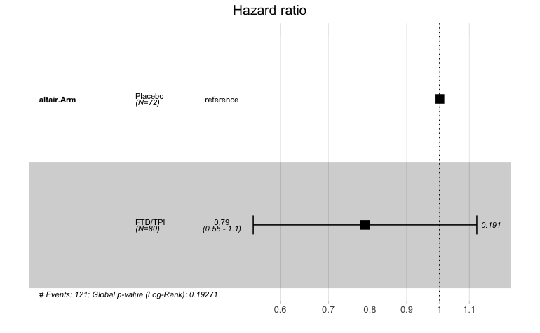

```r
circ_data$altair.Arm <- factor(circ_data$altair.Arm, levels=c("Control","Experimental"), labels = c("Placebo", "FTD/TPI"))
cox_fit <- coxph(surv_object ~ altair.Arm, data=circ_data)
ggforest(cox_fit,data = circ_data)
```

```r
summary(cox_fit)
```

```
Call:
coxph(formula = surv_object ~ altair.Arm, data = circ_data)

  n= 152, number of events= 121

                     coef exp(coef) se(coef)      z Pr(>|z|)
altair.ArmFTD/TPI -0.2391    0.7873   0.1829 -1.307    0.191

                  exp(coef) exp(-coef) lower .95 upper .95
altair.ArmFTD/TPI    0.7873       1.27    0.5501     1.127

Concordance= 0.559  (se = 0.025 )
Likelihood ratio test= 1.7  on 1 df,   p=0.2
Wald test            = 1.71  on 1 df,   p=0.2
Score (logrank) test = 1.72  on 1 df,   p=0.2
```

```r
cox_fit_summary <- summary(cox_fit)

# Extract values for HR, 95% CI, and p-value
HR <- cox_fit_summary$coefficients[2]
lower_CI <- cox_fit_summary$conf.int[3]
upper_CI <- cox_fit_summary$conf.int[4]
p_value <- cox_fit_summary$coefficients[5]
label_text <- paste0("HR = ", round(HR, 2), " (", round(lower_CI, 2), "-", round(upper_CI, 2), "); p = ", round(p_value, 3))
print(label_text)
```

```
[1] "HR = 0.79 (0.55-1.13); p = 0.191"
```

```r
#Fisher test for DFS percentages at 6, 12, 18 and 24 months
dfs_times <- c(6, 12, 18, 24)
p_values <- sapply(dfs_times, function(time) {
  neg_count <- sum(circ_data$altair.Arm == "FTD/TPI" & circ_data$DFS.months >= time & circ_data$p_evtDFS1b == 0)
  pos_count <- sum(circ_data$altair.Arm == "Placebo" & circ_data$DFS.months >= time & circ_data$p_evtDFS1b == 0)
  neg_total <- sum(circ_data$altair.Arm == "FTD/TPI")
  pos_total <- sum(circ_data$altair.Arm == "Placebo")

  neg_surv <- neg_total - sum(circ_data$altair.Arm == "FTD/TPI" & circ_data$p_evtDFS1b == 1 & circ_data$DFS.months < time)
  pos_surv <- pos_total - sum(circ_data$altair.Arm == "Placebo" & circ_data$p_evtDFS1b == 1 & circ_data$DFS.months < time)

  surv_matrix <- matrix(c(neg_surv, pos_surv, neg_total - neg_surv, pos_total - pos_surv), nrow = 2)
  test_result <- fisher.test(surv_matrix)
  return(test_result$p.value)
})
names(p_values) <- paste0("p-value at ", dfs_times, " months")
print(p_values)
```

```
 p-value at 6 months p-value at 12 months p-value at 18 months p-value at 24 months
        0.0001278464         0.3959706440         0.4666619773         0.6942842858
```

#Barplot with enrollment timepoint at any time by Arm

```r
rm(list=ls())
setwd("~/Downloads")
circ_data <- read.csv("Altair 20240729 Dataset.csv")

circ_data$altair.Arm <- factor(circ_data$altair.Arm, levels=c("Control","Experimental"), labels = c("Placebo", "FTD/TPI"))
circ_data$p_AltBaselineWin <- factor(circ_data$p_AltBaselineWin, levels = c("MRD", "OnTreatment", "Surveillance"), labels = c("MRD", "On Treatment", "Surveillance"))
contingency_table <- table(circ_data$altair.Arm, circ_data$p_AltBaselineWin)
chi_square_test <- chisq.test(contingency_table)
print(chi_square_test)
```

```
    Pearson's Chi-squared test

data:  contingency_table
X-squared = 1.2435, df = 2, p-value = 0.537
```

```r
fisher_exact_test <- fisher.test(contingency_table)
print(fisher_exact_test)
```

```
    Fisher's Exact Test for Count Data

data:  contingency_table
p-value = 0.5471
alternative hypothesis: two.sided
```

```r
print(contingency_table)
```

```
          MRD On Treatment Surveillance
  Placebo  30           19           72
  FTD/TPI  28           14           80
```

```r
p_values <- c(chi_square_test$p.value, fisher_exact_test$p.value)
p_adjusted <- p.adjust(p_values, method = "bonferroni")
names(p_adjusted) <- c("Chi-Square Test", "Fisher's Exact Test")
print(p_adjusted)
```

```
    Chi-Square Test Fisher's Exact Test
                  1                   1
```

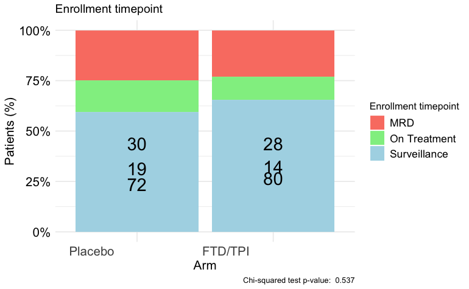

```r
table_df <- as.data.frame(contingency_table)
table_df$Total <- ave(table_df$Freq, table_df$Var1, FUN = sum)
table_df$Percentage <- table_df$Freq / table_df$Total
table_df$MiddlePercentage <- table_df$Percentage / 2
ggplot(table_df, aes(x = Var1, y = Percentage, fill = Var2)) +
  geom_bar(stat = "identity") +
  geom_text(aes(y = MiddlePercentage, label = Freq), position = "stack", color = "black", vjust = 1.5, size = 7) +
  theme_minimal() +
  labs(title = "Enrollment timepoint",
       x = "Arm",
       y = "Patients (%)",
       fill = "Enrollment timepoint",
       caption = paste("Chi-squared test p-value: ", format.pval(chi_square_test$p.value))) +
  scale_y_continuous(labels = scales::percent_format()) +
  scale_fill_manual(values = c("Surveillance" = "lightblue", "On Treatment" = "lightgreen", "MRD" = "salmon")) + # define custom colors
  theme(axis.text.x = element_text(angle = 0, hjust = 1.5, size = 14), # increase x-axis text size
        axis.text.y = element_text(size = 14, color = "black"), # increase y-axis text size
        axis.title.x = element_text(size = 14, color = "black"), # increase x-axis label size
        axis.title.y = element_text(size = 14, color = "black"), # increase y-axis label size
        legend.text = element_text(size = 12, color = "black"))  # increase Recurrence label size
```

```r
#Calculate median MTM/mL for enrollment timepoint
rm(list=ls())
setwd("~/Downloads")
circ_data <- read.csv("Altair 20240729 Dataset.csv")
result <- circ_data %>%
  group_by(p_AltBaselineWin) %>%
  summarise(
    Median = median(p_AltBaselineMTM, na.rm = TRUE),
    Range = paste(min(p_AltBaselineMTM, na.rm = TRUE), max(p_AltBaselineMTM, na.rm = TRUE), sep = " - ")
  )
print(result)
```

```
# A tibble: 3 × 3
  p_AltBaselineWin Median Range
  <chr>             <dbl> <chr>
1 MRD               0.972 0.026508782 - 121.2686353
2 OnTreatment       0.822 0.06015441805 - 166.3342558
3 Surveillance      0.240 0.02627334075 - 250.47
```

#Enrollment MTM/mL by ctDNA clearance in TAS-102 vs Placebo Arms

```r
#Placebo
rm(list=ls())
setwd("~/Downloads")
circ_data <- read.csv("Altair 20240729 Dataset.csv")
circ_data <- circ_data[circ_data$altair.group.SAP_MSv2!="1b = Exclude: No on-Tx TPs",]
circ_data <- circ_data[circ_data$altair.Arm=="Control",]

# Transform p_MRD_MTM with log10
circ_data$p_AltBaselineMTM <- as.numeric(as.character(circ_data$p_AltBaselineMTM))
circ_data$p_evtDFS1b <- factor(circ_data$p_evtDFS1b, levels=c("TRUE","FALSE"), labels = c("Recurrence", "No Recurrence"))
circ_data$altair.resultPatW <- factor(circ_data$altair.resultPatW, levels=c("No clearance", "Transient clearance", "Sustained clearance"))
median_p_MRD_MTM <- aggregate(p_AltBaselineMTM ~ altair.resultPatW, data = circ_data, FUN = median)
print(median_p_MRD_MTM)
```

```
    altair.resultPatW p_AltBaselineMTM
1        No clearance       0.63992898
2 Transient clearance       0.10612747
3 Sustained clearance       0.07446615
```

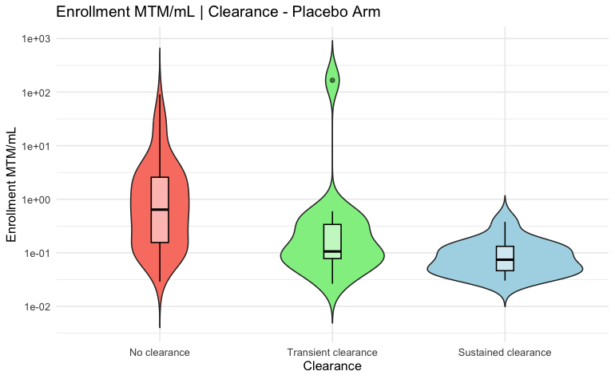

```r
# Create violin plot with log10 scale on y-axis
ggplot(circ_data, aes(x=altair.resultPatW, y=p_AltBaselineMTM, fill=altair.resultPatW)) +
  geom_violin(trim=FALSE) +
  scale_fill_manual(values=c("Sustained clearance"="lightblue", "Transient clearance"="lightgreen", "No clearance"="salmon")) +
  geom_boxplot(width=0.1, fill="white", colour="black", alpha=0.5) +
  scale_y_log10(breaks=c(0.001, 0.01, 0.1, 1, 10, 100, 1000, 10000)) +
  labs(title="Enrollment MTM/mL | Clearance - Placebo Arm", x="Clearance", y="Enrollment MTM/mL") +
  theme_minimal() +
  theme(legend.position="none")
```

```r
m3_1v2 <- wilcox.test(p_AltBaselineMTM ~ altair.resultPatW,
                      data = circ_data[circ_data$altair.resultPatW %in% c("Sustained clearance", "Transient clearance"), ],
                      na.rm = TRUE)
print(m3_1v2)
```

```
    Wilcoxon rank sum exact test

data:  p_AltBaselineMTM by altair.resultPatW
W = 153, p-value = 0.09254
alternative hypothesis: true location shift is not equal to 0
```

```r
m3_1v3 <- wilcox.test(p_AltBaselineMTM ~ altair.resultPatW,
                      data = circ_data[circ_data$altair.resultPatW %in% c("Sustained clearance", "No clearance"), ],
                      na.rm = TRUE)
print(m3_1v3)
```

```
    Wilcoxon rank sum test with continuity correction

data:  p_AltBaselineMTM by altair.resultPatW
W = 1053, p-value = 4.344e-06
alternative hypothesis: true location shift is not equal to 0
```

```r
m3_2v3 <- wilcox.test(p_AltBaselineMTM ~ altair.resultPatW,
                      data = circ_data[circ_data$altair.resultPatW %in% c("Transient clearance", "No clearance"), ],
                      na.rm = TRUE)
print(m3_2v3)
```

```
    Wilcoxon rank sum test with continuity correction

data:  p_AltBaselineMTM by altair.resultPatW
W = 1010, p-value = 0.002179
alternative hypothesis: true location shift is not equal to 0
```

```r
# Create a table with p-values
p_value_table <- data.frame(
  Comparison = c("Sustained vs Transient", "Sustained vs No Clearance", "Transient vs No Clearance"),
  P_Value = c(m3_1v2$p.value, m3_1v3$p.value, m3_2v3$p.value)
)
print(p_value_table)
```

```
                 Comparison      P_Value
1    Sustained vs Transient 9.253992e-02
2 Sustained vs No Clearance 4.344491e-06
3 Transient vs No Clearance 2.179474e-03
```

```r
#TAS-102
rm(list=ls())
setwd("~/Downloads")
circ_data <- read.csv("Altair 20240729 Dataset.csv")
circ_data <- circ_data[circ_data$altair.group.SAP_MSv2!="1b = Exclude: No on-Tx TPs",]
circ_data <- circ_data[circ_data$altair.Arm=="Experimental",]

# Transform p_MRD_MTM with log10
circ_data$p_AltBaselineMTM <- as.numeric(as.character(circ_data$p_AltBaselineMTM))
circ_data$p_evtDFS1b <- factor(circ_data$p_evtDFS1b, levels=c("TRUE","FALSE"), labels = c("Recurrence", "No Recurrence"))
circ_data$altair.resultPatW <- factor(circ_data$altair.resultPatW, levels=c("No clearance", "Transient clearance", "Sustained clearance"))
median_p_MRD_MTM <- aggregate(p_AltBaselineMTM ~ altair.resultPatW, data = circ_data, FUN = median)
print(median_p_MRD_MTM)
```

```
    altair.resultPatW p_AltBaselineMTM
1        No clearance        0.9419575
2 Transient clearance        0.1840031
3 Sustained clearance        0.4000000
```

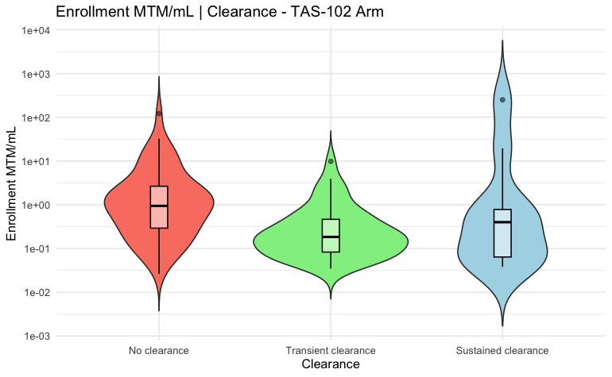

```r
# Create violin plot with log10 scale on y-axis
ggplot(circ_data, aes(x=altair.resultPatW, y=p_AltBaselineMTM, fill=altair.resultPatW)) +
  geom_violin(trim=FALSE) +
  scale_fill_manual(values=c("Sustained clearance"="lightblue", "Transient clearance"="lightgreen", "No clearance"="salmon")) +
  geom_boxplot(width=0.1, fill="white", colour="black", alpha=0.5) +
  scale_y_log10(breaks=c(0.001, 0.01, 0.1, 1, 10, 100, 1000, 10000)) +
  labs(title="Enrollment MTM/mL | Clearance - TAS-102 Arm", x="Clearance", y="Enrollment MTM/mL") +
  theme_minimal() +
  theme(legend.position="none")
```

```r
m3_1v2 <- wilcox.test(p_AltBaselineMTM ~ altair.resultPatW,
                      data = circ_data[circ_data$altair.resultPatW %in% c("Sustained clearance", "Transient clearance"), ],
                      na.rm = TRUE)
print(m3_1v2)
```

```
    Wilcoxon rank sum exact test

data:  p_AltBaselineMTM by altair.resultPatW
W = 241, p-value = 0.7395
alternative hypothesis: true location shift is not equal to 0
```

```r
m3_1v3 <- wilcox.test(p_AltBaselineMTM ~ altair.resultPatW,
                      data = circ_data[circ_data$altair.resultPatW %in% c("Sustained clearance", "No clearance"), ],
                      na.rm = TRUE)
print(m3_1v3)
```

```
    Wilcoxon rank sum test with continuity correction

data:  p_AltBaselineMTM by altair.resultPatW
W = 449, p-value = 0.09739
alternative hypothesis: true location shift is not equal to 0
```

```r
m3_2v3 <- wilcox.test(p_AltBaselineMTM ~ altair.resultPatW,
                      data = circ_data[circ_data$altair.resultPatW %in% c("Transient clearance", "No clearance"), ],
                      na.rm = TRUE)
print(m3_2v3)
```

```
    Wilcoxon rank sum test with continuity correction

data:  p_AltBaselineMTM by altair.resultPatW
W = 2201, p-value = 5.386e-06
alternative hypothesis: true location shift is not equal to 0
```

```r
# Create a table with p-values
p_value_table <- data.frame(
  Comparison = c("Sustained vs Transient", "Sustained vs No Clearance", "Transient vs No Clearance"),
  P_Value = c(m3_1v2$p.value, m3_1v3$p.value, m3_2v3$p.value)
)
print(p_value_table)
```

```
                 Comparison      P_Value
1    Sustained vs Transient 7.395008e-01
2 Sustained vs No Clearance 9.738952e-02
3 Transient vs No Clearance 5.386244e-06
```

#DFS1 by ctDNA Clearance with 3 groups - All stages

```r
rm(list=ls())
setwd("~/Downloads")
circ_data <- read.csv("Altair 20240729 Dataset.csv")
circ_data <- circ_data[circ_data$altair.group.SAP_MSv2!="1b = Exclude: No on-Tx TPs",]

circ_data$altair.resultPatW <- factor(circ_data$altair.resultPatW, levels=c("No clearance", "Transient clearance", "Sustained clearance"))
survfit(Surv(time = circ_data$DFS.months, event = circ_data$p_evtDFS1b)~altair.resultPatW, data = circ_data)
```

```
Call: survfit(formula = Surv(time = circ_data$DFS.months, event = circ_data$p_evtDFS1b) ~
    altair.resultPatW, data = circ_data)

                                        n events median 0.95LCL 0.95UCL
altair.resultPatW=No clearance        147    140   4.37    3.75    5.82
altair.resultPatW=Transient clearance  63     45  11.76   11.01   15.54
altair.resultPatW=Sustained clearance  25      5     NA   33.91      NA
```

```r
event_summary <- circ_data %>%
  group_by(altair.resultPatW) %>%
  summarise(
    Total = n(),
    Events = sum(p_evtDFS1b),
    Fraction = Events / n(),
    Percentage = (Events / n()) * 100
  )
print(event_summary)
```

```
# A tibble: 3 × 5
  altair.resultPatW   Total Events Fraction Percentage
  <fct>               <int>  <int>    <dbl>      <dbl>
1 No clearance          147    140    0.952       95.2
2 Transient clearance    63     45    0.714       71.4
3 Sustained clearance    25      5    0.2         20
```

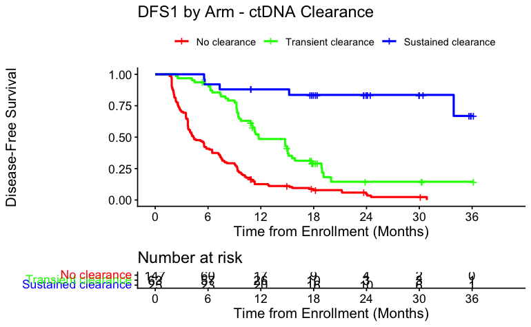

```r
surv_object <-Surv(time = circ_data$DFS.months, event = circ_data$p_evtDFS1b)
KM_curve <- survfit(surv_object ~ altair.resultPatW, data = circ_data,conf.int=0.95,conf.type="log-log")
ggsurvplot(KM_curve, data = circ_data, pval = FALSE, conf.int = FALSE, risk.table = TRUE, break.time.by=6, palette=c("red","green","blue"), title="DFS1 by Arm - ctDNA Clearance", ylab= "Disease-Free Survival", xlab="Time from Enrollment (Months)", legend.labs=c("No clearance", "Transient clearance",  "Sustained clearance"), legend.title="")
```

```r
summary(KM_curve, times= c(6, 12, 18, 24))
```

```
Call: survfit(formula = surv_object ~ altair.resultPatW, data = circ_data,
    conf.int = 0.95, conf.type = "log-log")

                altair.resultPatW=No clearance
 time n.risk n.event survival std.err lower 95% CI upper 95% CI
    6     60      87   0.4082  0.0405       0.3284       0.4862
   12     17      41   0.1262  0.0277       0.0782       0.1861
   18      9       6   0.0787  0.0232       0.0412       0.1319
   24      4       3   0.0472  0.0199       0.0183       0.0975

                altair.resultPatW=Transient clearance
 time n.risk n.event survival std.err lower 95% CI upper 95% CI
    6     57       5    0.920  0.0342       0.8192        0.966
   12     26      26    0.485  0.0653       0.3530        0.605
   18     10      10    0.290  0.0619       0.1767        0.414
   24      3       4    0.145  0.0600       0.0531        0.281

                altair.resultPatW=Sustained clearance
 time n.risk n.event survival std.err lower 95% CI upper 95% CI
    6     23       2    0.920  0.0543        0.716        0.979
   12     20       1    0.880  0.0650        0.673        0.960
   18     16       1    0.836  0.0752        0.619        0.935
   24     10       0    0.836  0.0752        0.619        0.935
```

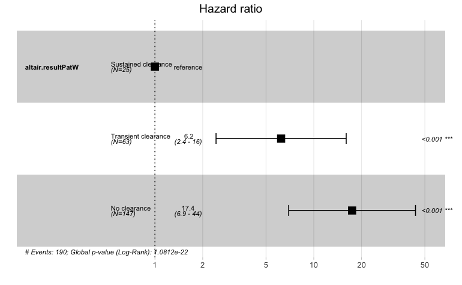

```r
circ_data$altair.resultPatW <- factor(circ_data$altair.resultPatW, levels=c("Sustained clearance", "Transient clearance", "No clearance"))
cox_fit <- coxph(surv_object ~ altair.resultPatW, data=circ_data)
ggforest(cox_fit,data = circ_data)
```

```r
summary(cox_fit)
```

```
Call:
coxph(formula = surv_object ~ altair.resultPatW, data = circ_data)

  n= 235, number of events= 190

                                        coef exp(coef) se(coef)     z Pr(>|z|)
altair.resultPatWTransient clearance  1.8292    6.2286   0.4812 3.801 0.000144 ***
altair.resultPatWNo clearance         2.8576   17.4200   0.4690 6.094  1.1e-09 ***
---
Signif. codes:  0 ‘***’ 0.001 ‘**’ 0.01 ‘*’ 0.05 ‘.’ 0.1 ‘ ’ 1

                                     exp(coef) exp(-coef) lower .95 upper .95
altair.resultPatWTransient clearance     6.229    0.16055     2.425     16.00
altair.resultPatWNo clearance           17.420    0.05741     6.948     43.67

Concordance= 0.686  (se = 0.017 )
Likelihood ratio test= 101.2  on 2 df,   p=<2e-16
Wald test            = 64.59  on 2 df,   p=9e-15
Score (logrank) test = 87.72  on 2 df,   p=<2e-16
```

```r
cox_fit_summary <- summary(cox_fit)
```

#OS by ctDNA Clearance with 3 groups - All stages

```r
rm(list=ls())
setwd("~/Downloads")
circ_data <- read.csv("Altair 20240729 Dataset.csv")
circ_data <- circ_data[circ_data$altair.group.SAP_MSv2!="1b = Exclude: No on-Tx TPs",]

circ_data$altair.resultPatW <- factor(circ_data$altair.resultPatW, levels=c("No clearance", "Transient clearance", "Sustained clearance"))
survfit(Surv(time = circ_data$OS.months, event = circ_data$p_evtOS)~altair.resultPatW, data = circ_data)
```

```
Call: survfit(formula = Surv(time = circ_data$OS.months, event = circ_data$p_evtOS) ~
    altair.resultPatW, data = circ_data)

                                        n events median 0.95LCL 0.95UCL
altair.resultPatW=No clearance        147     19     NA    40.7      NA
altair.resultPatW=Transient clearance  63      2     NA      NA      NA
altair.resultPatW=Sustained clearance  25      0     NA      NA      NA
```

```r
event_summary <- circ_data %>%
  group_by(altair.resultPatW) %>%
  summarise(
    Total = n(),
    Events = sum(p_evtOS),
    Fraction = Events / n(),
    Percentage = (Events / n()) * 100
  )
print(event_summary)
```

```
# A tibble: 3 × 5
  altair.resultPatW   Total Events Fraction Percentage
  <fct>               <int>  <int>    <dbl>      <dbl>
1 No clearance          147     19   0.129       12.9
2 Transient clearance    63      2   0.0317       3.17
3 Sustained clearance    25      0   0            0
```

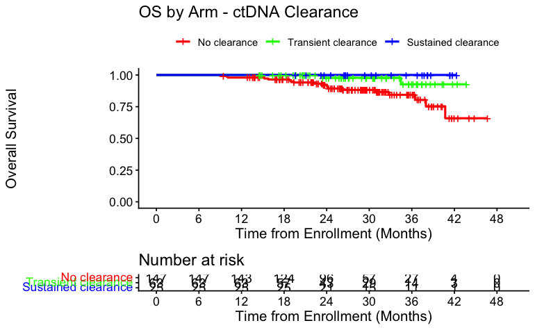

```r
surv_object <-Surv(time = circ_data$OS.months, event = circ_data$p_evtOS)
KM_curve <- survfit(surv_object ~ altair.resultPatW, data = circ_data,conf.int=0.95,conf.type="log-log")
ggsurvplot(KM_curve, data = circ_data, pval = FALSE, conf.int = FALSE, risk.table = TRUE, break.time.by=6, palette=c("red","green","blue"), title="OS by Arm - ctDNA Clearance", ylab= "Overall Survival", xlab="Time from Enrollment (Months)", legend.labs=c("No clearance", "Transient clearance",  "Sustained clearance"), legend.title="")
```

```r
summary(KM_curve, times= c(6, 12, 18, 24))
```

```
Call: survfit(formula = surv_object ~ altair.resultPatW, data = circ_data,
    conf.int = 0.95, conf.type = "log-log")

                altair.resultPatW=No clearance
 time n.risk n.event survival std.err lower 95% CI upper 95% CI
    6    147       0    1.000  0.0000        1.000        1.000
   12    143       3    0.979  0.0117        0.938        0.993
   18    124       2    0.965  0.0155        0.917        0.985
   24     96       5    0.923  0.0237        0.860        0.958

                altair.resultPatW=Transient clearance
 time n.risk n.event survival std.err lower 95% CI upper 95% CI
    6     63       0    1.000  0.0000        1.000        1.000
   12     63       0    1.000  0.0000        1.000        1.000
   18     57       0    1.000  0.0000        1.000        1.000
   24     43       1    0.978  0.0215        0.856        0.997

                altair.resultPatW=Sustained clearance
 time n.risk n.event survival std.err lower 95% CI upper 95% CI
    6     25       0        1       0            1            1
   12     25       0        1       0            1            1
   18     25       0        1       0            1            1
   24     21       0        1       0            1            1
```

```r
circ_data$altair.resultPatW <- factor(circ_data$altair.resultPatW, levels=c("Sustained clearance", "Transient clearance", "No clearance"))
cox_fit <- coxphf(surv_object ~ altair.resultPatW, data=circ_data)
summary(cox_fit)
```

```
coxphf(formula = surv_object ~ altair.resultPatW, data = circ_data)

Model fitted by Penalized ML
Confidence intervals and p-values by Profile Likelihood

                                         coef se(coef) exp(coef) lower 0.95 upper 0.95     Chisq          p
altair.resultPatWTransient clearance 1.004483 1.609325  2.730495   0.221318   377.0473 0.5145106 0.47319272
altair.resultPatWNo clearance        2.324182 1.489576 10.218322   1.391342  1302.7825 5.8730349 0.01537452

Likelihood ratio test=9.503886 on 2 df, p=0.008634899, n=235
Wald test = 5.724023 on 2 df, p = 0.05715369

Covariance-Matrix:
                                     altair.resultPatWTransient clearance altair.resultPatWNo clearance
altair.resultPatWTransient clearance                             2.589926                      2.162201
altair.resultPatWNo clearance                                    2.162201                      2.218837
```

```r
cox_fit_summary <- summary(cox_fit)
```

```
coxphf(formula = surv_object ~ altair.resultPatW, data = circ_data)

Model fitted by Penalized ML
Confidence intervals and p-values by Profile Likelihood

                                         coef se(coef) exp(coef) lower 0.95 upper 0.95     Chisq          p
altair.resultPatWTransient clearance 1.004483 1.609325  2.730495   0.221318   377.0473 0.5145106 0.47319272
altair.resultPatWNo clearance        2.324182 1.489576 10.218322   1.391342  1302.7825 5.8730349 0.01537452

Likelihood ratio test=9.503886 on 2 df, p=0.008634899, n=235
Wald test = 5.724023 on 2 df, p = 0.05715369

Covariance-Matrix:
                                     altair.resultPatWTransient clearance altair.resultPatWNo clearance
altair.resultPatWTransient clearance                             2.589926                      2.162201
altair.resultPatWNo clearance                                    2.162201                      2.218837
```

#DFS1 by ctDNA Clearance with 3 groups TAS-102 arm - All stages

```r
rm(list=ls())
setwd("~/Downloads")
circ_data <- read.csv("Altair 20240729 Dataset.csv")
circ_data$altair.Arm <- factor(circ_data$altair.Arm, levels = c("Control", "Experimental"), labels = c("Placebo", "FTD/TPI"))
circ_data <- circ_data[circ_data$altair.Arm=="FTD/TPI",]
circ_data <- circ_data[circ_data$altair.group.SAP_MSv2!="1b = Exclude: No on-Tx TPs",]

circ_data$altair.resultPatW <- factor(circ_data$altair.resultPatW, levels=c("No clearance", "Transient clearance", "Sustained clearance"))
survfit(Surv(time = circ_data$DFS.months, event = circ_data$p_evtDFS1b)~altair.resultPatW, data = circ_data)
```

```
Call: survfit(formula = Surv(time = circ_data$DFS.months, event = circ_data$p_evtDFS1b) ~
    altair.resultPatW, data = circ_data)

                                       n events median 0.95LCL 0.95UCL
altair.resultPatW=No clearance        62     60   5.67    3.94    7.82
altair.resultPatW=Transient clearance 47     35  11.30    9.73   15.15
altair.resultPatW=Sustained clearance 11      2     NA      NA      NA
```

```r
event_summary <- circ_data %>%
  group_by(altair.resultPatW) %>%
  summarise(
    Total = n(),
    Events = sum(p_evtDFS1b),
    Fraction = Events / n(),
    Percentage = (Events / n()) * 100
  )
print(event_summary)
```

```
# A tibble: 3 × 5
  altair.resultPatW   Total Events Fraction Percentage
  <fct>               <int>  <int>    <dbl>      <dbl>
1 No clearance           62     60    0.968       96.8
2 Transient clearance    47     35    0.745       74.5
3 Sustained clearance    11      2    0.182       18.2
```

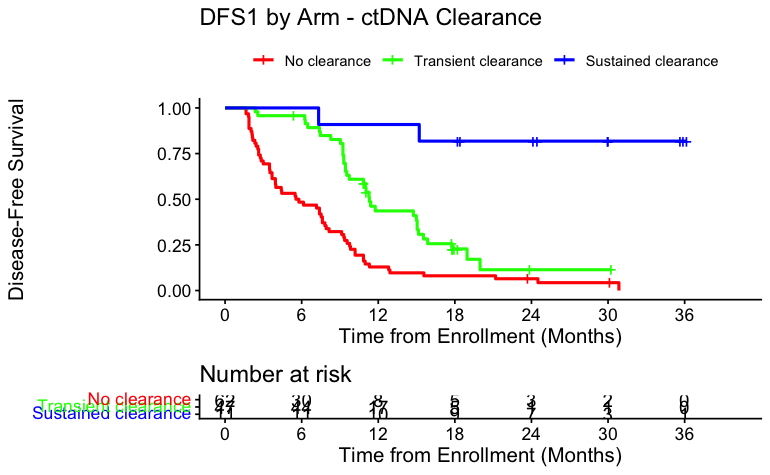

```r
surv_object <-Surv(time = circ_data$DFS.months, event = circ_data$p_evtDFS1b)
KM_curve <- survfit(surv_object ~ altair.resultPatW, data = circ_data,conf.int=0.95,conf.type="log-log")
ggsurvplot(KM_curve, data = circ_data, pval = FALSE, conf.int = FALSE, risk.table = TRUE, break.time.by=6, palette=c("red","green","blue"), title="DFS1 by Arm - ctDNA Clearance", ylab= "Disease-Free Survival", xlab="Time from Enrollment (Months)", legend.labs=c("No clearance", "Transient clearance",  "Sustained clearance"), legend.title="")
```

```r
summary(KM_curve, times= c(6, 12, 18, 24))
```

```
Call: survfit(formula = surv_object ~ altair.resultPatW, data = circ_data,
    conf.int = 0.95, conf.type = "log-log")

                altair.resultPatW=No clearance
 time n.risk n.event survival std.err lower 95% CI upper 95% CI
    6     30      32   0.4839  0.0635       0.3554        0.601
   12      8      22   0.1290  0.0426       0.0603        0.225
   18      5       3   0.0806  0.0346       0.0297        0.165
   24      3       1   0.0645  0.0312       0.0208        0.144

                altair.resultPatW=Transient clearance
 time n.risk n.event survival std.err lower 95% CI upper 95% CI
    6     44       2    0.957  0.0294       0.8404        0.989
   12     17      23    0.436  0.0758       0.2860        0.577
   18      5       8    0.228  0.0666       0.1133        0.366
   24      1       2    0.114  0.0660       0.0257        0.276

                altair.resultPatW=Sustained clearance
 time n.risk n.event survival std.err lower 95% CI upper 95% CI
    6     11       0    1.000  0.0000        1.000        1.000
   12     10       1    0.909  0.0867        0.508        0.987
   18      9       1    0.818  0.1163        0.447        0.951
   24      7       0    0.818  0.1163        0.447        0.951
```

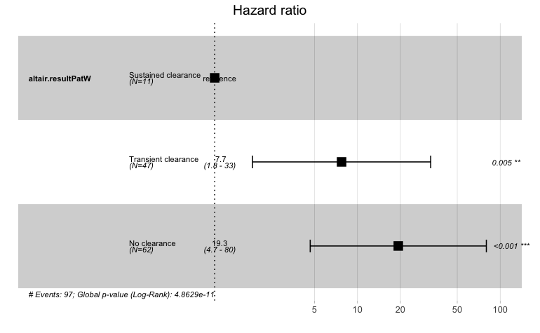

```r
circ_data$altair.resultPatW <- factor(circ_data$altair.resultPatW, levels=c("Sustained clearance", "Transient clearance", "No clearance"))
cox_fit <- coxph(surv_object ~ altair.resultPatW, data=circ_data)
ggforest(cox_fit,data = circ_data)
```

```r
summary(cox_fit)
```

```
Call:
coxph(formula = surv_object ~ altair.resultPatW, data = circ_data)

  n= 120, number of events= 97

                                        coef exp(coef) se(coef)     z Pr(>|z|)
altair.resultPatWTransient clearance  2.0466    7.7414   0.7334 2.791  0.00526 **
altair.resultPatWNo clearance         2.9611   19.3193   0.7247 4.086 4.39e-05 ***
---
Signif. codes:  0 ‘***’ 0.001 ‘**’ 0.01 ‘*’ 0.05 ‘.’ 0.1 ‘ ’ 1

                                     exp(coef) exp(-coef) lower .95 upper .95
altair.resultPatWTransient clearance     7.741    0.12918     1.839     32.59
altair.resultPatWNo clearance           19.319    0.05176     4.668     79.96

Concordance= 0.693  (se = 0.024 )
Likelihood ratio test= 47.49  on 2 df,   p=5e-11
Wald test            = 31.05  on 2 df,   p=2e-07
Score (logrank) test = 42.54  on 2 df,   p=6e-10
```

```r
cox_fit_summary <- summary(cox_fit)
```

#DFS1 by ctDNA Clearance with 3 groups Placebo arm - All stages

```r
rm(list=ls())
setwd("~/Downloads")
circ_data <- read.csv("Altair 20240729 Dataset.csv")
circ_data$altair.Arm <- factor(circ_data$altair.Arm, levels = c("Control", "Experimental"), labels = c("Placebo", "FTD/TPI"))
circ_data <- circ_data[circ_data$altair.Arm=="Placebo",]
circ_data <- circ_data[circ_data$altair.group.SAP_MSv2!="1b = Exclude: No on-Tx TPs",]

circ_data$altair.resultPatW <- factor(circ_data$altair.resultPatW, levels=c("No clearance", "Transient clearance", "Sustained clearance"))
survfit(Surv(time = circ_data$DFS.months, event = circ_data$p_evtDFS1b)~altair.resultPatW, data = circ_data)
```

```
Call: survfit(formula = Surv(time = circ_data$DFS.months, event = circ_data$p_evtDFS1b) ~
    altair.resultPatW, data = circ_data)

                                       n events median 0.95LCL 0.95UCL
altair.resultPatW=No clearance        85     80   4.11    3.71    5.55
altair.resultPatW=Transient clearance 16     10  14.75    7.98      NA
altair.resultPatW=Sustained clearance 14      3  33.91   33.91      NA
```

```r
event_summary <- circ_data %>%
  group_by(altair.resultPatW) %>%
  summarise(
    Total = n(),
    Events = sum(p_evtDFS1b),
    Fraction = Events / n(),
    Percentage = (Events / n()) * 100
  )
print(event_summary)
```

```
# A tibble: 3 × 5
  altair.resultPatW   Total Events Fraction Percentage
  <fct>               <int>  <int>    <dbl>      <dbl>
1 No clearance           85     80    0.941       94.1
2 Transient clearance    16     10    0.625       62.5
3 Sustained clearance    14      3    0.214       21.4
```

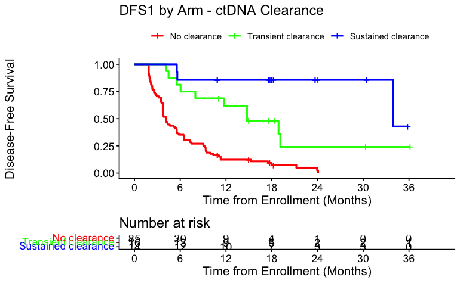

```r
surv_object <-Surv(time = circ_data$DFS.months, event = circ_data$p_evtDFS1b)
KM_curve <- survfit(surv_object ~ altair.resultPatW, data = circ_data,conf.int=0.95,conf.type="log-log")
ggsurvplot(KM_curve, data = circ_data, pval = FALSE, conf.int = FALSE, risk.table = TRUE, break.time.by=6, palette=c("red","green","blue"), title="DFS1 by Arm - ctDNA Clearance", ylab= "Disease-Free Survival", xlab="Time from Enrollment (Months)", legend.labs=c("No clearance", "Transient clearance",  "Sustained clearance"), legend.title="")
```

```r
summary(KM_curve, times= c(6, 12, 18, 24))
```

```
Call: survfit(formula = surv_object ~ altair.resultPatW, data = circ_data,
    conf.int = 0.95, conf.type = "log-log")

                altair.resultPatW=No clearance
 time n.risk n.event survival std.err lower 95% CI upper 95% CI
    6     30      55   0.3529  0.0518      0.25334        0.454
   12      9      19   0.1235  0.0365      0.06335        0.205
   18      4       3   0.0741  0.0314      0.02790        0.151
   24      1       2   0.0247  0.0227      0.00242        0.103

                altair.resultPatW=Transient clearance
 time n.risk n.event survival std.err lower 95% CI upper 95% CI
    6     13       3    0.812  0.0976       0.5246        0.935
   12      9       3    0.619  0.1230       0.3393        0.808
   18      5       2    0.481  0.1285       0.2241        0.699
   24      2       2    0.241  0.1364       0.0447        0.520

                altair.resultPatW=Sustained clearance
 time n.risk n.event survival std.err lower 95% CI upper 95% CI
    6     12       2    0.857  0.0935        0.539        0.962
   12     10       0    0.857  0.0935        0.539        0.962
   18      7       0    0.857  0.0935        0.539        0.962
   24      3       0    0.857  0.0935        0.539        0.962
```

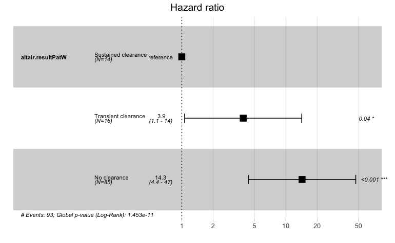

```r
circ_data$altair.resultPatW <- factor(circ_data$altair.resultPatW, levels=c("Sustained clearance", "Transient clearance", "No clearance"))
cox_fit <- coxph(surv_object ~ altair.resultPatW, data=circ_data)
ggforest(cox_fit,data = circ_data)
```

```r
summary(cox_fit)
```

```
Call:
coxph(formula = surv_object ~ altair.resultPatW, data = circ_data)

  n= 115, number of events= 93

                                        coef exp(coef) se(coef)     z Pr(>|z|)
altair.resultPatWTransient clearance  1.3595    3.8944   0.6613 2.056   0.0398 *
altair.resultPatWNo clearance         2.6623   14.3296   0.6066 4.389 1.14e-05 ***
---
Signif. codes:  0 ‘***’ 0.001 ‘**’ 0.01 ‘*’ 0.05 ‘.’ 0.1 ‘ ’ 1

                                     exp(coef) exp(-coef) lower .95 upper .95
altair.resultPatWTransient clearance     3.894    0.25678     1.066     14.23
altair.resultPatWNo clearance           14.330    0.06979     4.364     47.05

Concordance= 0.659  (se = 0.024 )
Likelihood ratio test= 49.91  on 2 df,   p=1e-11
Wald test            = 29.7  on 2 df,   p=4e-07
Score (logrank) test = 40.71  on 2 df,   p=1e-09
```

```r
cox_fit_summary <- summary(cox_fit)
```

#Central Review Imaging analysis #DFS1 by TAS vs Placebo - Central review data - All stages & stratified for Stage & ctDNA 1mo post-surgery

```r
rm(list = ls())
setwd("~/Downloads")
circ_data <- read.csv("Altair 20250903 Central Imaging Dataset.csv")
circ_data <- as.data.frame(circ_data)

circ_data$altair.Arm    <- factor(circ_data$altair.Arm, levels = c("Control","Experimental"), labels = c("Placebo","FTD/TPI"))
circ_data$Disease.Stage <- factor(circ_data$Disease.Stage, levels = c("Stage II or lower","StageIII","M1"))
circ_data$ctDNA1mo      <- factor(circ_data$ctDNA1mo, levels = c("NEGATIVE","POSITIVE"), labels = c("Negative","Positive"))

event_summary <- circ_data %>% group_by(altair.Arm) %>% summarise(Total = n(), Events = sum(p_evtDFS1b), Fraction = Events / n(), Percentage = (Events / n()) * 100)
print(event_summary)
```

```
# A tibble: 2 × 5
  altair.Arm Total Events Fraction Percentage
  <fct>      <int>  <int>    <dbl>      <dbl>
1 Placebo      121    100    0.826       82.6
2 FTD/TPI      122     96    0.787       78.7
```

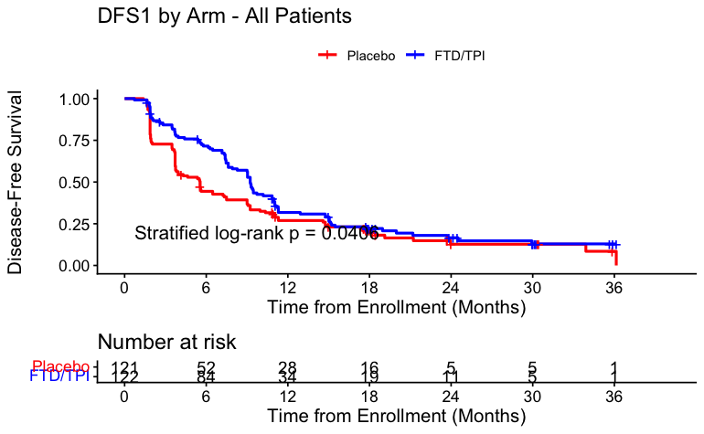

```r
surv_object <- Surv(time = circ_data$DFS.months, event = circ_data$p_evtDFS1b)
KM_curve <- survfit(surv_object ~ altair.Arm, data = circ_data, conf.int = 0.95, conf.type = "log-log")

# --- Stratified log-rank test (exactly as in primary analysis) ---
# Use survdiff with the same stratification factors
sd_strat <- survdiff(surv_object ~ altair.Arm + strata(Disease.Stage, ctDNA1mo), data = circ_data)
# For two groups, df = 1
p_strat_logrank <- 1 - pchisq(sd_strat$chisq, df = 1)

# KM plot with the stratified p-value displayed
ggsurvplot(KM_curve, data = circ_data, pval = sprintf("Stratified log-rank p = %.4f", p_strat_logrank), conf.int = FALSE, risk.table = TRUE, break.time.by = 6, palette = c("red","blue"), title = "DFS1 by Arm - All Patients", ylab = "Disease-Free Survival", xlab = "Time from Enrollment (Months)", legend.labs = c("Placebo", "FTD/TPI"), legend.title = "")
```

```r
print(summary(KM_curve, times = c(6, 12, 18, 24)))
```

```
Call: survfit(formula = surv_object ~ altair.Arm, data = circ_data,
    conf.int = 0.95, conf.type = "log-log")

                altair.Arm=Placebo
 time n.risk n.event survival std.err lower 95% CI upper 95% CI
    6     52      67    0.444  0.0453       0.3542        0.530
   12     28      20    0.269  0.0412       0.1923        0.352
   18     16       6    0.210  0.0386       0.1397        0.290
   24      5       5    0.127  0.0379       0.0649        0.212

                altair.Arm=FTD/TPI
 time n.risk n.event survival std.err lower 95% CI upper 95% CI
    6     84      34    0.716  0.0413       0.6254        0.788
   12     34      46    0.318  0.0434       0.2347        0.403
   18     19      10    0.222  0.0395       0.1494        0.303
   24     11       4    0.166  0.0381       0.0996        0.247
```

```r
cox_fit_stratified <- coxph(surv_object ~ altair.Arm + strata(Disease.Stage) + strata(ctDNA1mo), data = circ_data)
cox_fit_summary_stratified <- summary(cox_fit_stratified)
print(cox_fit_summary_stratified)
```

```
Call:
coxph(formula = surv_object ~ altair.Arm + strata(Disease.Stage) +
    strata(ctDNA1mo), data = circ_data)

  n= 243, number of events= 196

                     coef exp(coef) se(coef)      z Pr(>|z|)
altair.ArmFTD/TPI -0.3048    0.7372   0.1462 -2.085   0.0371 *
---
Signif. codes:  0 ‘***’ 0.001 ‘**’ 0.01 ‘*’ 0.05 ‘.’ 0.1 ‘ ’ 1

                  exp(coef) exp(-coef) lower .95 upper .95
altair.ArmFTD/TPI    0.7372      1.356    0.5536    0.9819

Concordance= 0.565  (se = 0.021 )
Likelihood ratio test= 4.34  on 1 df,   p=0.04
Wald test            = 4.35  on 1 df,   p=0.04
Score (logrank) test = 4.38  on 1 df,   p=0.04
```

```r
HR_stratified       <- cox_fit_summary_stratified$conf.int["altair.ArmFTD/TPI","exp(coef)"]
lower_CI_stratified <- cox_fit_summary_stratified$conf.int["altair.ArmFTD/TPI","lower .95"]
upper_CI_stratified <- cox_fit_summary_stratified$conf.int["altair.ArmFTD/TPI","upper .95"]

# --- Use SCORE (log-rank) p-value from the Cox fit ---
if (!is.null(cox_fit_summary_stratified$score)) {
  score_stat <- cox_fit_summary_stratified$score
} else {
  score_stat <- as.numeric(cox_fit_summary_stratified$sctest["test"])
}
p_value_score <- 1 - pchisq(score_stat, df = 1)

# (Optional) Wald p-value for reference
p_value_wald <- as.numeric(cox_fit_summary_stratified$wald["pvalue"])

# Label using SCORE p-value
label_text_stratified <- paste0(
  "HR = ", round(HR_stratified, 2),
  " (", round(lower_CI_stratified, 2), "-",
  round(upper_CI_stratified, 2), "); p (score) = ",
  format.pval(p_value_score, digits = 3)
)
print(label_text_stratified)
```

```
[1] "HR = 0.74 (0.55-0.98); p (score) = 0.036"
```

```r
#print both p-values side-by-side:
cat(sprintf("Stratified log-rank (survdiff) p = %.4f\n", p_strat_logrank))
```

```
Stratified log-rank (survdiff) p = 0.0406
```

```r
cat(sprintf("Cox score-test p = %.4f (Wald p = %.4f)\n", p_value_score, p_value_wald))
```

```
Cox score-test p = 0.0364 (Wald p = 0.0371)
```